# Figure 4

```r
library(tidyverse)
library(lubridate)
library(ggbeeswarm)
library(rstatix)
library(ggpubr)
library(wesanderson)
library(patchwork)
library(readxl)
library(ggdist)
library(grid)
library(survival)
library(survminer)
library(ggfortify)
library(scales)
source("func.R")
```

[output not shown]

Loading in data generated in previous steps:

```r
lung_mrca_tbl <- read_tsv("../results/lung_mrca_table.tsv")
lung_pairwise_l1  <- read_tsv("../results/lung_pairwise_l1.tsv")
crc_pairwise_l1  <- read_tsv("../results/crc_pairwise_l1.tsv")
crc_mrca_tbl <- read_tsv("../results/crc_mrca_table.tsv")
lung_markerlengths <- read_tsv("../results/lung_markerlengths.tsv")
```

Joining together tables for plotting:

```r
# filtering the data to only include the distance from the representative normal sample to each tumor sample

lung_normal  <- lung_pairwise_l1  %>%
    filter(tumor_a=="N1")  %>%
    mutate(cohort="Lung", divs=l1/9.43139014888478e-05)

crc_normal  <- crc_pairwise_l1  %>%
    filter(
        !str_detect(a, "A"), !str_detect(b, "A"),
        !(str_detect(a, "N")&str_detect(b, "N")),
        is.na(r)
        ) %>%
    mutate(cohort = "CRC Primary", subject = str_extract(a, "C[0-9]{1,3}")) %>%
    filter(!(subject %in% c("C92", "C95", "C6", "C38", "C12", "C102")))

dist_from_normal  <- bind_rows(lung_normal, crc_normal)  %>%
    mutate(cohort=fct_relevel(cohort, "Lung"))
```

## Fig4a: Showing clinical data

```r
clin_col_names <- c('subject','ngs_paper_id','sex','age','interval','survival','os','pf_survival','pfs','smoking','p1_size','p2_size','p3_size','n_stage','p1_lobe','p2_lobe','p3_lobe')
```

```r
# read in clinical data
clinical_info <- read_xlsx("../data/Supplementary_tables.xlsx", sheet = 1, skip = 2, col_names = clin_col_names)

pfs_info <- clinical_info %>%
    select(subject, pf_survival, pfs)

# rotating table so that each row features one tumor pair
int_clin <- clinical_info %>%
  select(subject, survival, os, interval, smoking, p1_lobe:p3_lobe, n_stage) %>%
  pivot_longer(p1_lobe:p3_lobe, names_to = "tumor", values_to = "lobe") %>%
  mutate(tumor = str_extract(tumor, "[1-3]")) %>%
  filter(!is.na(lobe))

# finding the size of the largest tumor
size_info <- clinical_info %>%
    select(subject, p1_size:p3_size, age, sex)

clinical_info_pairwise <- int_clin %>%
       select(subject, tumor, lobe) %>%
       rename(tumor_2 = tumor, lobe_2 = lobe) %>%
       left_join(int_clin, relationship = "many-to-many") %>%
       filter(tumor != tumor_2, tumor < tumor_2) %>%
       mutate(
              tumor_a = paste0("P", tumor),
              tumor_b = paste0("P", tumor_2)
       ) %>%
       select(-tumor, -tumor_2) %>%
           left_join(pfs_info) %>%
           left_join(size_info) %>%
           mutate(
               size_a = case_when(tumor_a == "P1" ~ p1_size, tumor_a == "P2" ~ p2_size, tumor_a == "P3" ~ p3_size),
               size_b = case_when(tumor_b == "P1" ~ p1_size, tumor_b == "P2" ~ p2_size, tumor_b == "P3" ~ p3_size)
           ) %>%
           select(-c(p1_size, p2_size, p3_size)) %>%
       mutate(size = pmax(size_a, size_b)) %>%
       mutate(id=paste(subject, tumor_a, tumor_b))
```

Total number of patients:

```r
clinical_info  %>%
    select(subject, p1_lobe, p2_lobe, p3_lobe)  %>%
    mutate(spread=case_when(p1_lobe==p2_lobe ~ "same_lobe",
                            str_sub(p1_lobe, 1,1) == str_sub(p2_lobe, 1,1) ~ "same_side",
                            TRUE ~ "other_side"))  %>%
    pivot_longer(cols = p1_lobe:p3_lobe, names_to = "tumor", values_to = "lobe") %>%
    drop_na() %>%
    pull(subject)  %>%
    n_distinct()
```

34

Number of individual tumors

```r
clinical_info  %>%
    select(subject, p1_lobe, p2_lobe, p3_lobe)  %>%
    mutate(spread=case_when(p1_lobe==p2_lobe ~ "same_lobe",
                            str_sub(p1_lobe, 1,1) == str_sub(p2_lobe, 1,1) ~ "same_side",
                            TRUE ~ "other_side"))  %>%
    pivot_longer(cols = p1_lobe:p3_lobe, names_to = "tumor", values_to = "lobe") %>%
    drop_na() %>%
    nrow()
```

73

```r
clinical_info %>%
       select(subject, p1_lobe, p2_lobe, p3_lobe)  %>%
    mutate(spread=case_when(p1_lobe==p2_lobe ~ "same_lobe",
                            str_sub(p1_lobe, 1,1) == str_sub(p2_lobe, 1,1) ~ "same_side",
                            TRUE ~ "other_side"))  %>%
    pivot_longer(cols = p1_lobe:p3_lobe, names_to = "tumor", values_to = "lobe") %>%
    drop_na() %>%
    count(tumor)
```

A tibble: 3 x 2

| tumor <chr> | n <int> |
| --- | --- |
| p1_lobe | 34 |
| p2_lobe | 34 |
| p3_lobe | 5 |

Finding number of tumors at each location.

```r
clinical_info_pairwise %>%
       filter(!is.na(lobe)) %>%
    mutate(location = case_when(
        lobe == lobe_2 ~ "Same lobe",
        str_sub(lobe, start = 1, end = 1) == str_sub(lobe_2, start = 1, end = 1) ~ "Same lung",
        TRUE ~ "Other lung"
    ), location=fct_relevel(location, "Same lobe", "Same lung", "Other lung")) %>%
    count(location)
```

A tibble: 3 x 2

| location <fct> | n <int> |
| --- | --- |
| Same lobe | 8 |
| Same lung | 19 |
| Other lung | 17 |

Time from resection of first tumor to the second resected tumor.

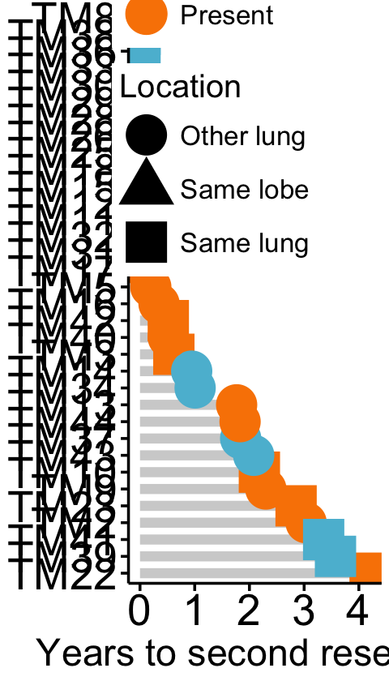

```r
clinical_info %>%
    mutate(
        ln_met = ifelse(n_stage == 0, "Present", "Absent"),
        timing = ifelse(interval > 2, "metachronous", "synchronous"),
        ln_met = fct_relevel(ln_met, "Absent", "Present"),
        Location = case_when(
            p1_lobe == p2_lobe ~ "Same lobe",
            str_sub(p1_lobe, start = 1, end = 1) == str_sub(p2_lobe, start = 1, end = 1) ~ "Same lung",
            TRUE ~ "Other lung"
        ), subject = fct_reorder(subject, -interval), interval = interval / 12,
    ) %>%
    ggplot(aes(subject, interval)) +
    geom_segment(aes(y=0, yend=interval, x=subject, xend=subject, group=subject), linewidth=3.5, color="grey82") +
    geom_point(aes(y=interval, color=ln_met, shape=Location), size=14
              ) +
    coord_flip() +
    scale_color_manual(name="Lymphatic metastases", values=c(Present=wes_palette("Darjeeling1")[4], Absent=wes_palette("Darjeeling1")[5])) +
    theme_martin() +
    theme(legend.text = element_text(size = 20), legend.title = element_text(size = 24),
              legend.position = c(0.6, 0.87), axis.title.y = element_blank(),
               axis.title.x = element_text(size=28)
         ) +
    labs(y = "Years to second resection")
ggsave("../plots/Figure4/Extended_Data_Fig7a.pdf", height=20, width=12)
```

## MSS classification of lung cancer

```r
# ordering subjects from lowest to highest number
subjects <- lung_markerlengths %>%
    pull(subject) %>%
    unique() %>%
    str_sort(numeric = TRUE) %>%
    as.list()
```

```r
# no subjects classified as MSI
lung_markerlengths %>%
    group_by(subject) %>%
    mutate(large_del = (length < (-1))) %>%
    count(large_del) %>%
    mutate(del_frac = n / sum(n)) %>%
    filter(large_del, del_frac > 0.1)
```

A grouped_df: 0 x 4

| subject | large_del | n | del_frac |
| --- | --- | --- | --- |
| <chr> | <lgl> | <int> | <dbl> |

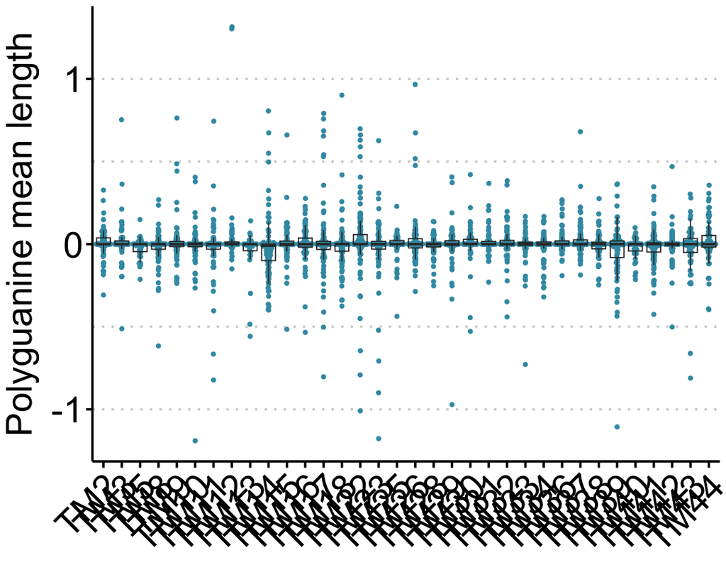

```r
lung_markerlengths %>%
    mutate(
        subject = fct_relevel(subject, subjects)
    ) %>%
    ggplot(aes(subject, length)) +
    geom_quasirandom(color=wes_palette("Zissou1")[1]) +
    geom_boxplot(alpha = 0) +
    scale_y_continuous(breaks = seq(-10, 10, 1)) +
    labs(y = "Polyguanine mean length") +
    theme_martin() +
    theme(
            axis.title.x = element_blank(), axis.text.x = element_text(angle = 45, hjust = 1),
            panel.grid.major.y = element_line(size = 1, color = "grey82", linetype = 3),
            panel.grid.minor.y = element_line(size = 1, color = "grey82", linetype = 3),
            legend.key.height = unit(20, "pt"), legend.key.width = unit(20, "pt"),
            legend.text = element_text(size = 28), legend.title = element_text(size=28)
      ) +
    guides(colour = guide_legend(override.aes = list(size=12)))
ggsave("../plots/Figure4/Extended_Data_Fig10b.pdf", height=11, width=22)
```

```r
n_counts <- lung_markerlengths %>%
    mutate(
        subject = fct_relevel(subject, subjects)
    ) %>%
    group_by(subject) %>%
        count() %>%
        mutate(n=paste0("n=", n))
```

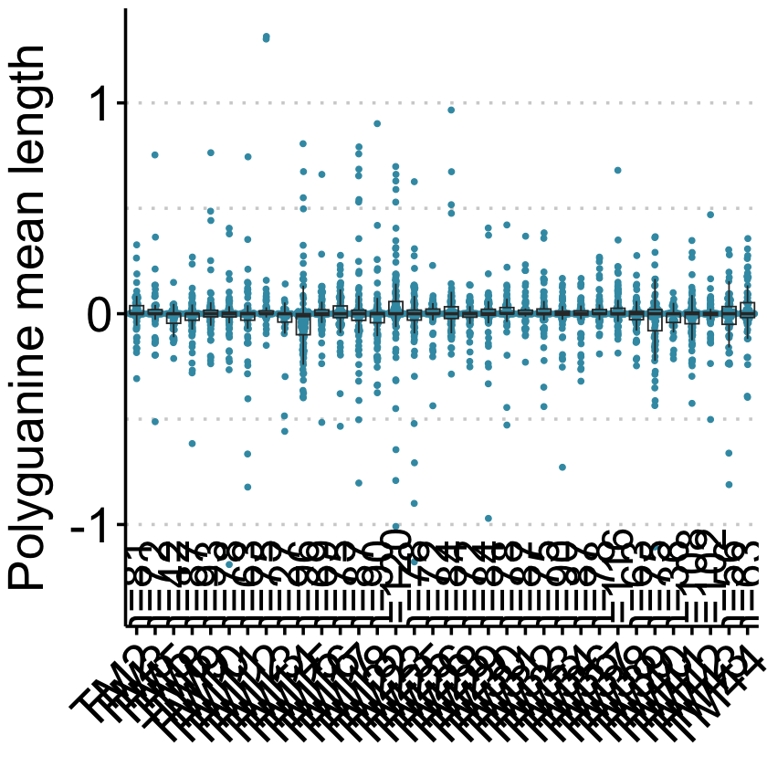

```r
lung_markerlengths %>%
    mutate(
        subject = fct_relevel(subject, subjects)
    ) %>%
    ggplot(aes(subject, length)) +
        geom_quasirandom(color = wes_palette("Zissou1")[1]) +
        geom_boxplot(alpha = 0) +
        geom_text(data=n_counts, aes(y=-1.3, label=n), angle=90, size=10) +
    scale_y_continuous(breaks = seq(-10, 10, 1)) +
    coord_cartesian(ylim=c(-1.35, NA)) +
    labs(y = "Polyguanine mean length") +
    theme_martin() +
    theme(
            axis.title.x = element_blank(), axis.text.x = element_text(angle = 45, hjust = 1),
            panel.grid.major.y = element_line(size = 1, color = "grey82", linetype = 3),
            panel.grid.minor.y = element_line(size = 1, color = "grey82", linetype = 3),
            legend.key.height = unit(20, "pt"), legend.key.width = unit(20, "pt"),
            legend.text = element_text(size = 28), legend.title = element_text(size=28)
      ) +
    guides(colour = guide_legend(override.aes = list(size = 12)))
ggsave("../plots/Supplementary_figures/Supplementary_Fig10.pdf", height=11, width=22)
```

## Figs 4C-E

```r
dist_from_normal %>%
    group_by(cohort, subject) %>%
    ungroup() %>%
    wilcox_test(divs ~ cohort) %>%
    p_format(accuracy = 1e-50, add.p = TRUE, digits = 1) %>%
    add_xy_position(x = "cohort")  %>%
    mutate(y.position=log10(y.position))
```

A rstatix_test: 1 x 11

| .y. <chr> | group1 <chr> | group2 <chr> | n1 <int> | n2 <int> | statistic <dbl> | p <chr> | y.position <dbl> | groups <named list> | xmin <dbl> | xmax <dbl> |
| --- | --- | --- | --- | --- | --- | --- | --- | --- | --- | --- |
| divs | Lung | CRC Primary | 73 | 348 | 2125 | p=5e-29 | 3.794243 | Lung , CRC Primary | 1 | 2 |

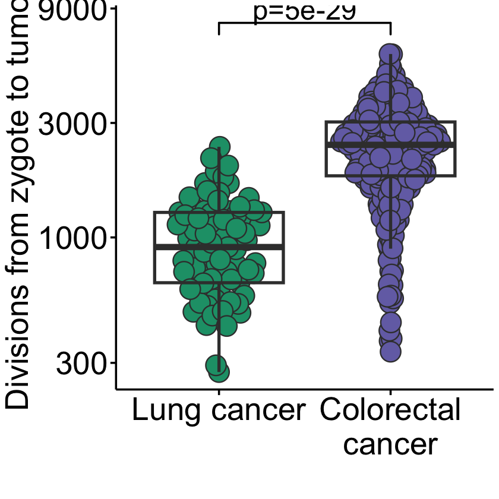

```r
from_normal_wilcox  <- dist_from_normal %>%
    group_by(cohort, subject) %>%
    ungroup() %>%
    wilcox_test(divs ~ cohort) %>%
    p_format(accuracy = 1e-50, add.p = TRUE, digits = 1) %>%
    add_xy_position(x = "cohort")  %>%
    mutate(y.position=log10(y.position))

dist_from_normal %>%
    group_by(cohort, subject) %>%
    ggplot(aes(cohort, divs)) +
    geom_quasirandom(aes(fill=cohort),  width=0.3, size=9, pch=21, color="grey23", stroke=1) +
    geom_boxplot(alpha=0, size=1.5, color="grey23") +
    scale_fill_manual(values = c("CRC Primary"="#7570B3", "Lung"="#1B9E77"),
                       guide="none") +
    stat_pvalue_manual(from_normal_wilcox, label = "p", tip.length = 0.015, step.increase = 0.04,
                      bracket.nudge.y = 0.1, size = 10, bracket.size = 1) +
    labs(x = "", y = "Divisions from zygote to tumor", ) +
    theme_martin() +
    scale_y_log10(breaks=c(300,1000,3000,9000)) +
    scale_x_discrete(labels= c("Lung cancer", "Colorectal\ncancer")) +
    theme(text = element_text(size = 20, color="black"),
         axis.text = element_text(color="black"),
         axis.ticks = element_line(color="black"))

ggsave("../plots/Figure4/Fig4C.pdf",
      height=10, width=11)
```

```r
dist_from_normal %>%
    group_by(cohort) %>%
    summarize(median(divs), n=n())
```

A tibble: 2 x 3

| cohort <fct> | median(divs) <dbl> | n <int> |
| --- | --- | --- |
| Lung | 911.5835 | 73 |
| CRC Primary | 2431.7124 | 348 |

```r
dist_from_normal %>%
    write_tsv("~/Downloads/fig4c_data.tsv")
```

```r
dist_from_normal %>%
    group_by(cohort) %>%
    summarize(divs = median(divs)) %>%
    summarise(divs_ratio=divs[cohort=="CRC Primary"]/divs[cohort=="Lung"])
```

A tibble: 1 x 1

| divs_ratio <dbl> |
| --- |
| 2.66757 |

Purity adjusted cell division burden

```r
# vector of normal samples in batch2
normal_samples_vector <- c("CC001_5", "T790M_III_1_N", "CC002_11", "CC005_11", "WGS00C_N20",
                      "WGS00E_N22", "CC006_3", "WGS00D_N8")
```

```r
# directroy of all Burr et al lung cancer data batch1
dir_list <-  list.files("../data/batch1/",
                        pattern= "_R$", full.names = TRUE)

## Creating Marker Length Table
l1 <- lapply(dir_list, get_markerlengths)

batch1_meanlengths <- l1 %>%
    bind_rows() %>%
    mutate(normal=ifelse(str_detect(sample, "N"), TRUE, FALSE), batch=1)

# directroy of all Burr et al lung cancer data batch1
dir_list <-  list.files("../data/batch2/",
                        pattern= "_R$", full.names = TRUE)

## Creating Marker Length Table
l2 <- lapply(dir_list, get_markerlengths)

batch2_meanlengths <- l2 %>%
    bind_rows() %>%
    mutate(normal = ifelse(sample %in% normal_samples_vector, TRUE, FALSE), batch=2)

burr_meanlengths_raw <- bind_rows(batch1_meanlengths) %>%
    bind_rows(batch2_meanlengths)
```

```
CC003

WGS002

WGS004

WGS005

CC001

CC002

CC005

T790M

WGS00C

WGS00D

WGS00E
```

```r
# calculating meanlength from normal
burr_meanlengths <- burr_meanlengths_raw %>%
    group_by(batch, subject, marker) %>%
    mutate(length=length-length[normal])
```

```r
# function to get markers that are present in all samples
get_sampler_marker  <- function(sample_i, marker_tbl) {

    marker_tbl  %>%
    filter(sample==sample_i)  %>%
    pull(marker)  %>%
    unique()
}

get_minimum_marker_table  <- function(subject_i, markerlengths){

marker_tbl <-  markerlengths  %>%
    filter(subject==subject_i)  %>%
    group_by(sample)  %>%
    add_count(sample)  %>%
    ungroup()  %>%
    mutate(minimum_markers = max(n)*0.7) %>%
    filter(n>minimum_markers)

samples  <- unique(marker_tbl$sample)
marker_list  <- lapply(samples, get_sampler_marker, marker_tbl)
common_markers  <- Reduce(intersect, marker_list)

n_common_markers  <- length(common_markers)

markerlengths  %>%
    filter(subject==subject_i, marker %in% common_markers)   %>%
    group_by(sample)  %>%
    add_count(sample)  %>%
    filter(n==n_common_markers)  %>%
    select(-n)

    }
```

```r
# getting all marker lengths from normal
subjects  <- unique(burr_meanlengths$subject)
minimum_marker_tbls_burr  <- lapply(subjects, get_minimum_marker_table, burr_meanlengths)
minimum_marker_tbls_burr  <- bind_rows(minimum_marker_tbls_burr)
```

```r
# find samples
samples <- minimum_marker_tbls_burr$sample %>% unique

combos_wide <- combn(samples, m= 2) %>% as.data.frame()

## make combo table longer
combos_long <- data.frame(a=as.character(combos_wide[1,]), b=as.character(combos_wide[2,]))

## only use combintions from the same subject
combos <- combos_long %>%
    mutate(
        sample_a = str_remove(a, "[N|P][:alnum:]+"),
        sample_b = str_remove(b, "[N|P][:alnum:]+")
    ) %>%
    mutate(sample_a = str_remove(sample_a, "_.*"),
        sample_b = str_remove(b, "_.*")) %>%
    filter(sample_a==sample_b) %>%
    dplyr::select(a, b)
```

Calculating uncorrected l1

```r
# create a table for the L1 of non-bootstrapped marker lengths
burr_l1 <- lapply(1:nrow(combos), get_l1_r_for_combination, combos, minimum_marker_tbls_burr)
burr_l1_uncorrected <- rbindlist(burr_l1)
```

Calculating corrected l1

Excluding clearly pre-invasive, in situ, and lepidic tumors to match Yang et al. cohort.

```r
burr_purities <- read_excel("../data/burr_purities.xlsx") %>%
    drop_na() %>%
    filter(
        !str_detect(Histology, "MIA|situ|AIS|AAH|pre-neoplastic "),
        Purity != "<0.05"
    ) %>%
    mutate(
        purity = as.numeric(Purity),
        sample = str_replace(Tumor, "-", "_"),
        sample = ifelse(str_detect(sample, "T790M"), str_remove(sample, "_1"), sample)
    ) %>%
    select(sample, purity)
```

Purity correction of markerlengths

```r
burr_meanlengths_raw %>%
    left_join(burr_purities) %>%
    filter(!is.na(purity) | sample %in% normal_samples_vector | str_detect(sample, "N"), sample != "T790M_III_1_N2") %>%
    filter(purity > 0.3) %>%
    group_by(batch, subject) %>%
    add_count() %>%
    filter(n==max(n)) %>%
    group_by(batch, subject, marker) %>%
    mutate(purity=ifelse(is.na(purity),1,purity)) %>%
    filter(subject=="WGS004", marker=="JF21")
```

A grouped_df: 1 x 8

| sample <chr> | length <dbl> | marker <chr> | subject <chr> | normal <lgl> | batch <dbl> | purity <dbl> | n <int> |
| --- | --- | --- | --- | --- | --- | --- | --- |
| WGS004P2 | 2.14031 | JF21 | WGS004 | FALSE | 1 | 0.43 | 38 |

```r
burr_meanlengths_raw %>%
    left_join(burr_purities) %>%
    filter(!is.na(purity) | sample %in% normal_samples_vector | str_detect(sample, "N"), sample != "T790M_III_1_N2") %>%
    filter(purity > 0.3 |  str_detect(sample, "N"), sample != "T790M_III_1_N2") %>%
    group_by(batch, subject) %>%
    add_count() %>%
    filter(subject == "CC001")
```

A grouped_df: 23 x 8

| sample <chr> | length <dbl> | marker <chr> | subject <chr> | normal <lgl> | batch <dbl> | purity <dbl> | n <int> |
| --- | --- | --- | --- | --- | --- | --- | --- |
| CC001_1 | 3.319654 | JF21 | CC001 | FALSE | 2 | 0.48 | 23 |
| CC001_1 | 1.913924 | Nax10 | CC001 | FALSE | 2 | 0.48 | 23 |
| CC001_1 | 2.805343 | Nax11 | CC001 | FALSE | 2 | 0.48 | 23 |
| CC001_1 | 3.638408 | Nax17 | CC001 | FALSE | 2 | 0.48 | 23 |
| CC001_1 | 3.661599 | Nax18 | CC001 | FALSE | 2 | 0.48 | 23 |
| CC001_1 | 3.341935 | Nax30 | CC001 | FALSE | 2 | 0.48 | 23 |
| CC001_1 | 2.785864 | Nax40 | CC001 | FALSE | 2 | 0.48 | 23 |
| CC001_1 | 1.976270 | Nax43 | CC001 | FALSE | 2 | 0.48 | 23 |
| CC001_1 | 3.687634 | Nax47 | CC001 | FALSE | 2 | 0.48 | 23 |
| CC001_1 | 3.844908 | Nax50 | CC001 | FALSE | 2 | 0.48 | 23 |
| CC001_1 | 2.701546 | Nax51 | CC001 | FALSE | 2 | 0.48 | 23 |
| CC001_1 | 3.260485 | Nax55 | CC001 | FALSE | 2 | 0.48 | 23 |
| CC001_1 | 2.731739 | Nax56 | CC001 | FALSE | 2 | 0.48 | 23 |
| CC001_1 | 1.982303 | Nax68 | CC001 | FALSE | 2 | 0.48 | 23 |
| CC001_1 | 2.475839 | Sal22 | CC001 | FALSE | 2 | 0.48 | 23 |
| CC001_1 | 3.014024 | Sal27 | CC001 | FALSE | 2 | 0.48 | 23 |
| CC001_1 | 2.601656 | Sal45 | CC001 | FALSE | 2 | 0.48 | 23 |
| CC001_1 | 2.598105 | Sal46 | CC001 | FALSE | 2 | 0.48 | 23 |
| CC001_1 | 1.358105 | Sal58 | CC001 | FALSE | 2 | 0.48 | 23 |
| CC001_1 | 1.917617 | Sal66 | CC001 | FALSE | 2 | 0.48 | 23 |
| CC001_1 | 2.624937 | Sal74 | CC001 | FALSE | 2 | 0.48 | 23 |
| CC001_1 | 1.620455 | Sal78 | CC001 | FALSE | 2 | 0.48 | 23 |
| CC001_1 | 2.251986 | Sal87 | CC001 | FALSE | 2 | 0.48 | 23 |

```r
burr_meanlengths_corrected <- burr_meanlengths_raw %>%
    left_join(burr_purities) %>%
    filter(!is.na(purity) | sample %in% normal_samples_vector | str_detect(sample, "N"), sample != "T790M_III_1_N2") %>%
    filter(purity > 0.3 |  str_detect(sample, "N") | sample %in% normal_samples_vector, sample != "T790M_III_1_N2") %>%
    group_by(batch, subject) %>%
    add_count() %>%
    filter(n==max(n)) %>%
    group_by(batch, subject, marker) %>%
    mutate(purity=ifelse(is.na(purity),1,purity)) %>%
    mutate(length = (length - (1 - purity) * length[normal]) / purity) %>%
    mutate(length=length-length[normal])  %>%
    select(-n)
```

```r
# getting all marker lengths from normal
subjects  <- unique(burr_meanlengths_corrected$subject)
minimum_marker_tbls_burr_corrected  <- lapply(subjects, get_minimum_marker_table, burr_meanlengths_corrected)
minimum_marker_tbls_burr_corrected  <- bind_rows(minimum_marker_tbls_burr_corrected)
```

```r
# find samples
samples <- minimum_marker_tbls_burr_corrected$sample %>% unique

combos_wide <- combn(samples, m= 2) %>% as.data.frame()

## make combo table longer
combos_long <- data.frame(a=as.character(combos_wide[1,]), b=as.character(combos_wide[2,]))

## only use combintions from the same subject
combos <- combos_long %>%
    mutate(
        sample_a = str_remove(a, "[N|P][:alnum:]+"),
        sample_b = str_remove(b, "[N|P][:alnum:]+")
    ) %>%
    mutate(sample_a = str_remove(sample_a, "_.*"),
        sample_b = str_remove(b, "_.*")) %>%
    filter(sample_a==sample_b) %>%
    dplyr::select(a, b)

# create a table for the L1 of non-bootstrapped marker lengths
burr_l1 <- lapply(1:nrow(combos), get_l1_r_for_combination, combos, minimum_marker_tbls_burr_corrected)
burr_l1_corrected <- rbindlist(burr_l1)
```

```r
burr_dist_from_normal_corrected <- burr_l1_corrected %>%
    filter((a %in% normal_samples_vector) | (b %in% normal_samples_vector)) %>%
    mutate(sample=ifelse(a%in%normal_samples_vector, b , a), divs=l1/9.43139014888478e-05, cohort="burr_corr")
```

```r
cor_samples <- burr_dist_from_normal_corrected$sample
```

```r
burr_dist_from_normal_uncorrected <- burr_l1_uncorrected %>%
    filter((a %in% normal_samples_vector) | (b %in% normal_samples_vector)) %>%
    mutate(sample=ifelse(a%in%normal_samples_vector, b , a), divs=l1/9.43139014888478e-05, cohort="burr_uncorr") %>%
    filter(sample %in% cor_samples)
```

```r
burr_dist_from_normal_corrected %>%
    write_tsv("../results/burr_corrected.tsv")

burr_dist_from_normal_uncorrected %>%
    write_tsv("../results/burr_uncorrected.tsv")
```

Normalizing the mutational burden:

```r
# polyG data
polyg_norm_mut <- dist_from_normal %>%
    filter(cohort=="Lung") %>%
    select(b, l1, cohort) %>%
    rename(sample = b) %>%
    mutate(norm_mut = l1 / median(l1), cohort="polyg")
```

```r
tcga_data <- read_tsv("../data/mutation_burden/tcga.tsv")

# all NSCLC and colorectal cancer cases were downloaded from TCGA
tcga_data %>%
    pull(`TCGA PanCanAtlas Cancer Type Acronym`) %>%
    unique()
```

1. 'LUAD'

2. 'LUSC'

3. 'COAD'

4. 'READ'

```r
# MSI and POLE mutant subtypes were excluded
tcga_data %>%
    pull(Subtype) %>%
    unique()

mmrd_cancers <- tcga_data %>%
    filter(`TCGA PanCanAtlas Cancer Type Acronym`!="LUSC", `Subtype` %in% c("LUAD", "COAD_CIN", "COAD_GS", "READ_CIN", "READ_GS"))
```

1. 'LUAD'

2. NA

3. 'LUSC'

4. 'COAD_CIN'

5. 'COAD_MSI'

6. 'COAD_GS'

7. 'COAD_POLE'

8. 'READ_CIN'

9. 'READ_GS'

10. 'READ_POLE'

11. 'READ_MSI'

```r
tcga_norm_mut <- mmrd_cancers %>%
    rename(TCGA = `TCGA PanCanAtlas Cancer Type Acronym`, mb = `Mutation Count`) %>%
    filter(!is.na(mb)) %>%
    group_by(TCGA) %>%
    mutate(TCGA = ifelse(TCGA == "READ", "COAD", TCGA), norm_mut = mb / median(mb), cohort = "exome") %>%
    ungroup() %>%
    mutate(TCGA = fct_relevel(TCGA, "LUAD", "COAD"))
```

```r
tcga_norm_mut %>%
    count(TCGA)
```

A tibble: 2 x 2

| TCGA <fct> | n <int> |
| --- | --- |
| COAD | 386 |
| LUAD | 501 |

```r
tcga_norm_mut %>%
  wilcox_test(mb ~ TCGA) %>%
  p_format(accuracy = 1e-50, add.p = TRUE)
```

A rstatix_test: 1 x 7

|  | .y. <chr> | group1 <chr> | group2 <chr> | n1 <int> | n2 <int> | statistic <dbl> | p <chr> |
| --- | --- | --- | --- | --- | --- | --- | --- |
| 1 | mb | COAD | LUAD | 386 | 501 | 59921.5 | p=2.5e-22 |

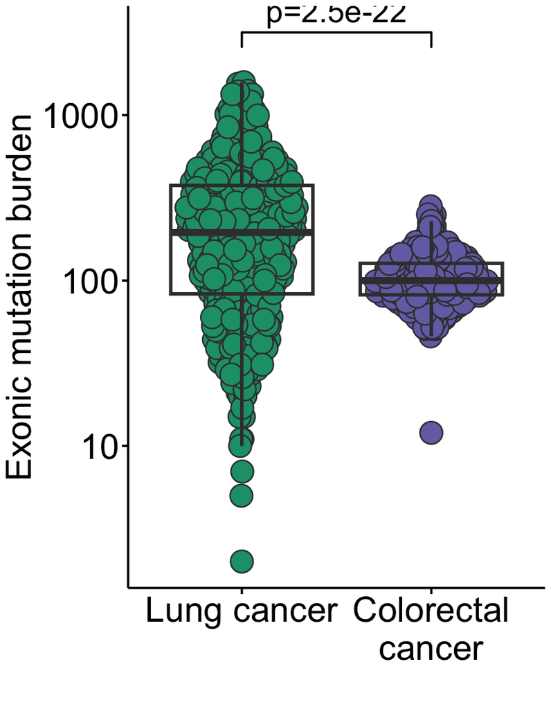

```r
# getting wilcoxon test p-value
wilcox_p <- tcga_norm_mut %>%
  wilcox_test(mb ~ TCGA) %>%
  p_format(accuracy = 1e-50, add.p = TRUE) %>%
  pull(p)

  tcga_norm_mut %>%
        ggplot(aes(TCGA, mb)) +
        geom_quasirandom(aes(fill = TCGA), width = 0.3, size = 9, pch = 21, color = "grey23", stroke = 1) +
        geom_boxplot(alpha = 0, size = 1.5, color = "grey23") +
        geom_bracket(
        xmin = 1, xmax = 2, y.position = 3.5,
        label = wilcox_p, size=1, label.size = 10, vjust=-0.2
        ) +
        scale_fill_manual(
            values = c(
                "COAD" = "#7570B3", "LUAD" = "#1B9E77"
            ),
            guide = "none"
        ) +
        scale_y_log10() +
          labs(x = "", y = "Exonic mutation burden", ) +
          theme_martin() +
          scale_x_discrete(labels = c("Lung cancer", "Colorectal\ncancer")) +
          theme(
            text = element_text(size = 20, color = "black"),
            axis.text = element_text(color = "black"),
            axis.ticks = element_line(color = "black")
          )
  ggsave("../plots/Figure4/Fig4D.pdf", height=10, width=11)
```

#### Plotting distributions side by side

TCGA vs PolyG

```r
bind_rows(polyg_norm_mut, tcga_norm_mut %>%
    filter(TCGA=="LUAD")) %>%
    mutate(x=ifelse(cohort=="exome", 0.85, 1.9)) %>%
    count(cohort)
```

A tibble: 2 x 2

| cohort <chr> | n <int> |
| --- | --- |
| exome | 501 |
| polyg | 73 |

```r
bind_rows(polyg_norm_mut, tcga_norm_mut %>%
filter(TCGA=="LUAD") ) %>%
  mutate(norm_mut = log10(norm_mut), cohort = as.factor(cohort)) %>%
  levene_test(norm_mut ~ cohort)
```

A tibble: 1 x 4

| df1 <int> | df2 <int> | statistic <dbl> | p <dbl> |
| --- | --- | --- | --- |
| 1 | 572 | 39.61884 | 6.148505e-10 |

[figure not shown]

```r
options(repr.plot.width=7, repr.plot.height=9)

# finding levene_test p-value
var_test <- bind_rows(polyg_norm_mut, tcga_norm_mut %>%
filter(TCGA=="LUAD") ) %>%
  mutate(norm_mut = log10(norm_mut), cohort = as.factor(cohort)) %>%
  levene_test(norm_mut ~ cohort) %>%
  p_format(accuracy = 1e-50, add.p = TRUE) %>%
  pull(p)

  var_test <- paste0("Variance comparison\n", var_test)

bind_rows(polyg_norm_mut, tcga_norm_mut %>%
    filter(TCGA=="LUAD")) %>%
    mutate(x=ifelse(cohort=="exome", 0.85, 1.9)) %>%
    ggplot(aes(x, norm_mut, group=cohort)) +
    ggdist::stat_slab(aes(fill = cohort),
           justification = -.35,
           normalize = "xy",
           width=0.6,
           alpha=0.8) +
    geom_point(position = position_jitter(seed = 36, width = .06), size = 2, color = "grey78") +
      geom_boxplot(width = .25, size = 1.5, outlier.shape = NA, alpha = 0) +
      geom_bracket(
        xmin = 1.3, xmax = 2.3, y.position = 1.1, tip.length = 0.04,
        label = var_test, size = 1, label.size = 10
      ) +
    scale_fill_manual(values = c("exome"="grey50",
                                 "CRC Primary"="firebrick2", "polyg"="#1B9E77"),
                      guide="none") +
    labs(y = "Normalized mutation burden", ) +
    theme_martin() +
    scale_y_log10(expand = expansion(add = c(0.5, 0.45)), breaks = c(0.01, 0.1, 1, 10)) +
    scale_x_continuous(
    limits = c(.55, NA),
    breaks = 1:2,
    labels = c("Exome", "Polyguanine\nrepeats"),
  )  +
    theme(
        text = element_text(size = 20, color = "black"),
        axis.text = element_text(color = "black"),
        axis.ticks = element_line(color = "black"),
        axis.title.x = element_blank())
ggsave("../plots/Figure4/Fig4E.pdf", height=11, width=10)
```

SBS 1 burden

```r
sp_sbs <- read_csv("../data/mutation_burden/PCAWG_sigProfiler_SBS_signatures_in_samples.csv")
```

```r
sp_sbs %>%
  dplyr::rename(type = 1, sample = 2) %>%
  select(1, 2, 4) %>%
  group_by(type, sample) %>%
  filter(SBS1!=0) %>%
  summarise(mut=log10(sum(SBS1))) %>%
  filter((type=="Lung-AdenoCA" | type=="ColoRect-AdenoCA")) %>%
  mutate(type=case_match(type, "Lung-AdenoCA"~"LUAD", "ColoRect-AdenoCA"~"CRC")) %>%
  ungroup() %>%
  wilcox_test(mut ~ type) %>%
  mutate(p=paste0("p=", p))
```

A rstatix_test: 1 x 7

| .y. <chr> | group1 <chr> | group2 <chr> | n1 <int> | n2 <int> | statistic <dbl> | p <chr> |
| --- | --- | --- | --- | --- | --- | --- |
| mut | CRC | LUAD | 60 | 36 | 2159 | p=3.29e-16 |

'p=3.29e-16'

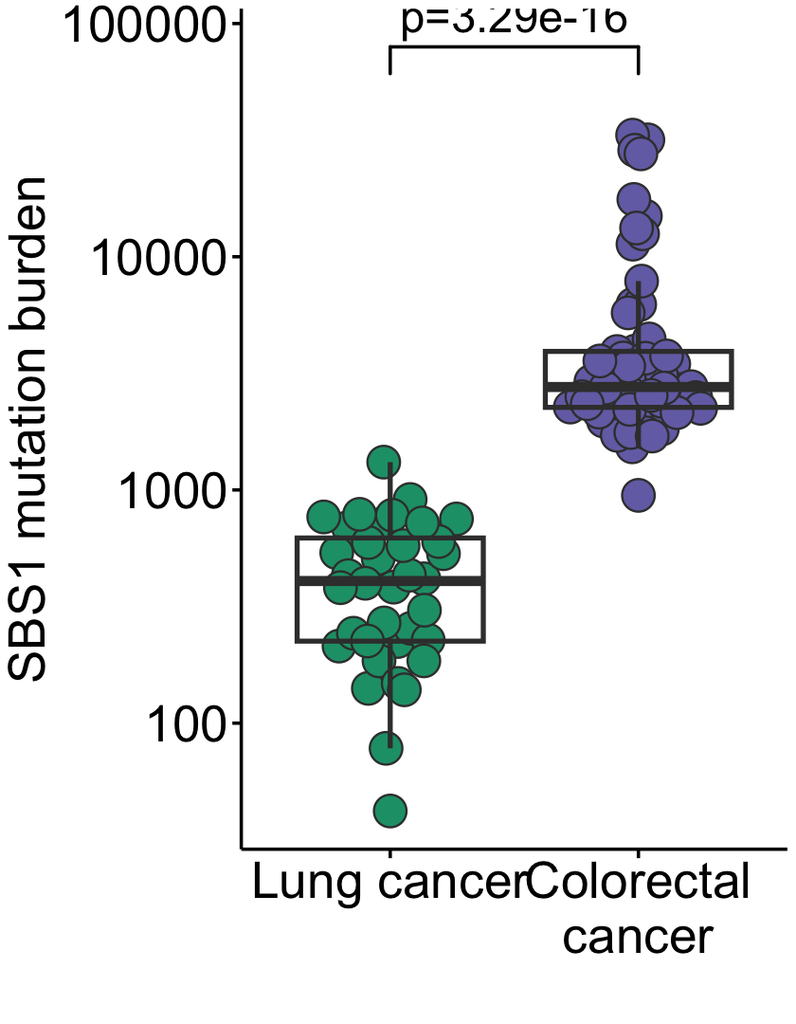

```r
# getting wilcoxon test p-value
wilcox_p <- sp_sbs %>%
  dplyr::rename(type = 1, sample = 2) %>%
  select(1, 2, 4) %>%
  group_by(type, sample) %>%
  filter(SBS1 != 0) %>%
  summarise(mut = log10(sum(SBS1))) %>%
  filter((type == "Lung-AdenoCA" | type == "ColoRect-AdenoCA")) %>%
  mutate(type = case_match(type, "Lung-AdenoCA" ~ "LUAD", "ColoRect-AdenoCA" ~ "CRC")) %>%
  ungroup() %>%
  wilcox_test(mut ~ type) %>%
  mutate(p = paste0("p=", p)) %>%
  pull(p)
wilcox_p
 sp_sbs %>%
  dplyr::rename(type = 1, sample = 2) %>%
  select(1, 2, 4) %>%
  group_by(type, sample) %>%
  filter(SBS1!=0) %>%
  summarise(mut=sum(SBS1)) %>%
  filter((type=="Lung-AdenoCA" | type=="ColoRect-AdenoCA")) %>%
  mutate(type=case_match(type, "Lung-AdenoCA"~"LUAD", "ColoRect-AdenoCA"~"CRC")) %>%
  ungroup() %>%
  mutate(type=fct_relevel(type, "LUAD", "CRC")) %>%
  ggplot(aes(type, mut)) +
  geom_quasirandom(aes(fill = type), width = 0.3, size = 9, pch = 21, color = "grey23", stroke = 1) +
  geom_boxplot(alpha = 0, size = 1.5, color = "grey23") +
  geom_bracket(
  xmin = 1, xmax = 2, y.position = 4.9,
  label = wilcox_p, size=1, label.size = 10, vjust=-0.2
  ) +
  scale_fill_manual(
      values = c(
          "CRC" = "#7570B3", "LUAD" = "#1B9E77"
      ),
      guide = "none"
  ) +
  scale_y_log10(labels = label_number(big.mark = "")) +
    labs(x = "", y = "SBS1 mutation burden", ) +
    theme_martin() +
    scale_x_discrete(labels = c("Lung cancer", "Colorectal\ncancer")) +
    theme(
      text = element_text(size = 20, color = "black"),
      axis.text = element_text(color = "black"),
      axis.ticks = element_line(color = "black")
    )
  ggsave("../plots/Figure4/Extended_Data_Fig7c.pdf", height=11, width=11)
```

```r
sp_sbs %>%
  dplyr::rename(type = 1, sample = 2) %>%
  select(1, 2, 4) %>%
  group_by(type, sample) %>%
  filter(SBS1!=0) %>%
  summarise(mut=sum(SBS1)) %>%
  filter((type=="Lung-AdenoCA" | type=="ColoRect-AdenoCA")) %>%
  mutate(type=case_match(type, "Lung-AdenoCA"~"LUAD", "ColoRect-AdenoCA"~"CRC")) %>%
  ungroup() %>%
  mutate(type=fct_relevel(type, "LUAD", "CRC")) %>%
  count(type)
```

A tibble: 2 x 2

| type <fct> | n <int> |
| --- | --- |
| LUAD | 36 |
| CRC | 60 |

Numbers

```r
bind_rows(polyg_norm_mut, sbs1_lung) %>%
  mutate(x = ifelse(cohort == "SBS1", 0.85, 1.9)) %>%
  filter(norm_mut > 0) %>%
  group_by(cohort) %>%
  count()
```

A grouped_df: 2 x 2

| cohort <chr> | n <int> |
| --- | --- |
| SBS1 | 36 |
| polyg | 73 |

## Fig4B, F: MRCA timing of lung cancers

Plotting the timing of each tumor pair:

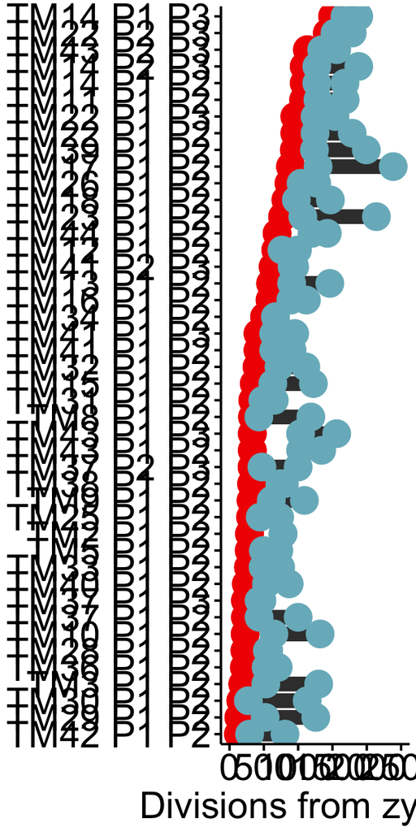

```r
options(repr.plot.width=5, repr.plot.height=10)


lung_mrca_tbl  %>%
    pivot_longer(2:5, names_to="mrca", values_to="divs") %>%
    filter(mrca!="all_mrca", !is.na(divs))  %>%
    mutate(row_id=as.factor(row_number()),
          tumor_a=str_split(mrca, "_")  %>% purrr::map(1)  %>% toupper(),
          tumor_b=str_split(mrca, "_")  %>% purrr::map(2)  %>% toupper())  %>%
    pivot_longer(tumor_a:tumor_b, values_to="tumor_b", names_to="x")  %>%
    left_join(lung_normal  %>%
                rename(divs_n=divs)) %>%
    group_by(subject, mrca)  %>%
    unite(subject, mrca, col = "id") %>%
    mutate(id=str_remove(id, "_mrca")  %>%
                      toupper()  %>%
                      str_replace_all("_", " "))  %>%
    mutate(id = fct_reorder(id, divs, max)) %>%
    ggplot(aes(id)) +
    geom_blank() +
    geom_line(aes(y=divs_n, group=id), size=6, color="grey23") +
    geom_point(aes(y=divs, color=status), size=11,
              color=wes_palette("Zissou1")[5]
              ) +
    geom_point(aes(y = divs_n), size = 11, color = wes_palette("Zissou1")[2]) +
    coord_flip(ylim=c(0,2500)) +
    labs(y="Divisions from zygote") +
    theme_martin() +
    theme(axis.title.y = element_blank(),
          legend.position = c(0.9, 0.4)
      )

ggsave("../plots/Figure4/Fig4B.pdf",
      width=12, height=29.5)
```

Density function of MRCA timing:

```r
library(ggtext)
```

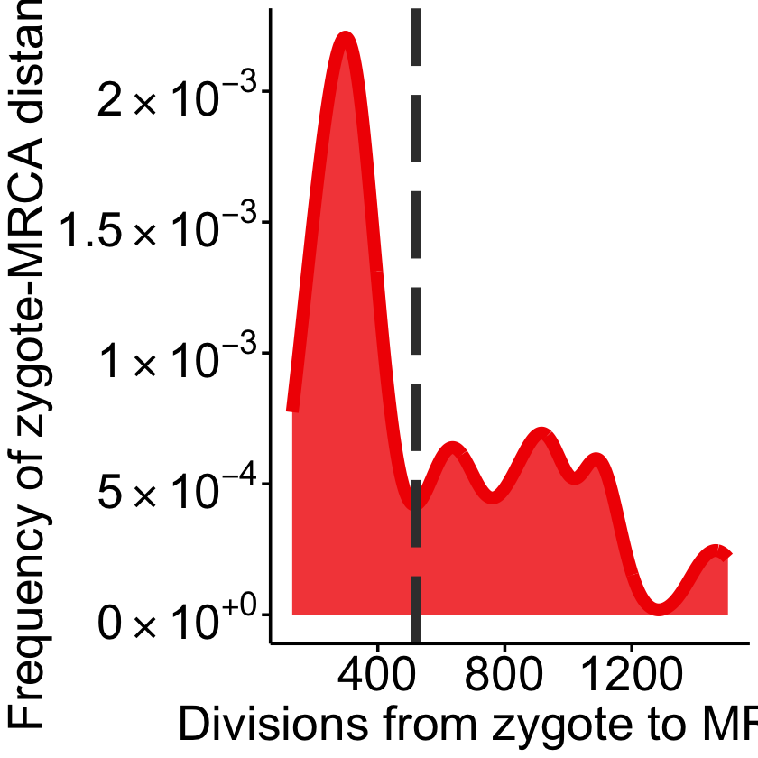

```r
options(repr.plot.width=7, repr.plot.height=7)

scientific_10 <- function(x) {

     parse(text = gsub("e", " %*% 10^", scales::scientific_format()(x)))
}

lung_mrca_tbl %>%
    pivot_longer(2:5, names_to = "mrca", values_to = "divs") %>%
    mutate(Divisions = "to mrca") %>%
    filter(mrca != "all_mrca", !is.na(divs)) %>%
    ggplot(aes(divs, after_stat(density), fill = Divisions, color = Divisions)) +
    geom_density(alpha = 0.8, size = 4, bw = 60, outline.type = "upper", show.legend = FALSE, trim = FALSE, kernel="gaussian") +
    geom_vline(xintercept = 520, linetype = 5, size = 3, color = "grey23") +
    scale_fill_manual(values = c(wes_palette("Zissou1")[5])) +
    scale_color_manual(values = c(wes_palette("Zissou1")[5])) +
    scale_y_continuous(
              labels =scientific_10
              ) +
    labs(x = "Divisions from zygote to MRCA", y="Frequency of zygote-MRCA distances") +
    theme_martin()

ggsave("../plots/Figure4/Fig4F.pdf", height=11, width=12)
```

Finding local minimum of density function above:

```r
lung_mrca_tbl  %>%
    pivot_longer(2:5, names_to="mrca", values_to="divs")  %>%
    mutate(Divisions="to mrca")  %>%
    filter(mrca != "all_mrca", !is.na(divs)) %>%
    pull(divs) %>%
    max()
```

1502.81232891676

```r
# density function with same binwidth as in the plot
den <- lung_mrca_tbl  %>%
    pivot_longer(2:5, names_to="mrca", values_to="divs")  %>%
    filter(mrca != "all_mrca", !is.na(divs)) %>%
    pull(divs) %>%
    density(bw = 60)

# estimation of local minimum should only start at the minimum number of observed cell divisions
min_divs <- lung_mrca_tbl  %>%
    pivot_longer(2:5, names_to="mrca", values_to="divs")  %>%
    mutate(Divisions="to mrca")  %>%
    filter(mrca != "all_mrca", !is.na(divs)) %>%
    pull(divs) %>%
    min()

# finding the positions in the density function between smallest and largest observed cell divisions
max_x <- max(which(den$x < 1000))
min_x <- min(which(den$x > min_divs))

# finding the position in the density function of the local minimum
loc_min <- which(den$y[min_x:max_x] == min(den$y[min_x:max_x]))

# finding the position in the density function of the local maximum
loc_max <- which(den$y[min_x:max_x] == max(den$y[min_x:max_x]))

# finding the cell divisions value at the local minimum
message(paste("Local minimum at", den$x[min_x:max_x][loc_min], "divisions."))

# finding the cell divisions value at the local minimum
message(paste("Local maximum at", den$x[min_x:max_x][loc_max], "divisions."))
```

```
Local minimum at 516.495411043407 divisions.

Local maximum at 299.506217020457 divisions.
```

Counting tumor pairs with divergence before and after 520 cell divisions.

```r
paste("Number of tumor pairs:", length(lung_mrca_tbl %>%
    pivot_longer(2:5, names_to = "mrca", values_to = "divs") %>%
    filter(mrca != "all_mrca", !is.na(divs)) %>%
    pull(divs)))

paste("Divergence before 520 divisions:", sum(lung_mrca_tbl %>%
    pivot_longer(2:5, names_to = "mrca", values_to = "divs") %>%
    filter(mrca != "all_mrca", !is.na(divs)) %>%
    pull(divs) < 520))

paste("Divergence after 520 divisions:", (44 - 26))
```

'Number of tumor pairs: 44'

'Divergence before 520 divisions: 26'

'Divergence after 520 divisions: 18'

## Figs 4G-H

Data pre-processing

```r
# processing information from sequencing paper
ngs_data <- read_excel("../data/yang_paper_s3.xlsx")

old_names <- clinical_info %>%
    select(1:2) %>%
    rename(old_id = ngs_paper_id) %>%
    mutate(old_id = as.character(old_id))

ngs_new_names <- ngs_data %>%
    filter(if_any(everything(), ~ !is.na(.)), !str_detect(`Pair ID`, "NA")) %>%
    mutate(across(1:10, ~ str_remove_all(.x, " "))) %>%
    rename(old_id = 1) %>%
    separate(old_id, c(NA, "tumor"), "_", remove = FALSE) %>%
    mutate(tumor_a = case_when(
        is.na(tumor) ~ "P1",
        tumor == "T1vsT2" ~ "P1",
        tumor == "T1vsT3" ~ "P1",
        tumor == "T2vsT3" ~ "P2",
    ), tumor_b = case_when(
        is.na(tumor) ~ "P2",
        tumor == "T1vsT2" ~ "P2",
        tumor == "T1vsT3" ~ "P3",
        tumor == "T2vsT3" ~ "P3",
    ),
    old_id=str_remove_all(old_id, "_.*")) %>%
    select(old_id, tumor_a, tumor_b, NGS, Histology) %>%
    left_join(old_names) %>%
    drop_na() %>%
    select(-old_id)

# preparing data
join_ngs_names <- ngs_new_names %>%
    mutate(id = paste(subject, tumor_a, tumor_b)) %>%
    select(-c(tumor_a, tumor_b))
```

```r
# setting up data
clinical_divs <- lung_mrca_tbl %>%
      pivot_longer(2:5, names_to = "mrca", values_to = "divs") %>%
      filter(mrca != "all_mrca", !is.na(divs)) %>%
      mutate(
            tumor_a = str_split(mrca, "_") %>% purrr::map(1) %>% toupper(),
            tumor_b = str_split(mrca, "_") %>% purrr::map(2) %>% toupper()
      ) %>%
      select(-mrca) %>%
      left_join(ngs_new_names) %>%
      drop_na() %>%
      mutate(id = paste(subject, tumor_a, tumor_b)) %>%
      mutate(across(c(NGS, Histology), ~ case_match(.x, "IPM" ~ "Met", "SPLC" ~ "Ind")))
```

Comparing divisions to MRCA with orthogonal classifications.

```r
p_hist <- clinical_divs %>%
    filter(Histology %in% c("Ind", "Met")) %>%
    wilcox_test(divs ~ Histology) %>%
    add_xy_position() %>%
    mutate(p = paste0("p=", format(p, scientific = T)))
p_hist
```

A rstatix_test: 1 x 11

| .y. <chr> | group1 <chr> | group2 <chr> | n1 <int> | n2 <int> | statistic <dbl> | p <chr> | y.position <dbl> | groups <named list> | xmin <dbl> | xmax <dbl> |
| --- | --- | --- | --- | --- | --- | --- | --- | --- | --- | --- |
| divs | Ind | Met | 18 | 19 | 50 | p=2.5e-04 | 1568.918 | Ind, Met | 1 | 2 |

```r
clinical_divs %>%
      filter(Histology %in% c("Ind", "Met")) %>%
      count(Histology)
```

A tibble: 2 x 2

| Histology <chr> | n <int> |
| --- | --- |
| Ind | 18 |
| Met | 19 |

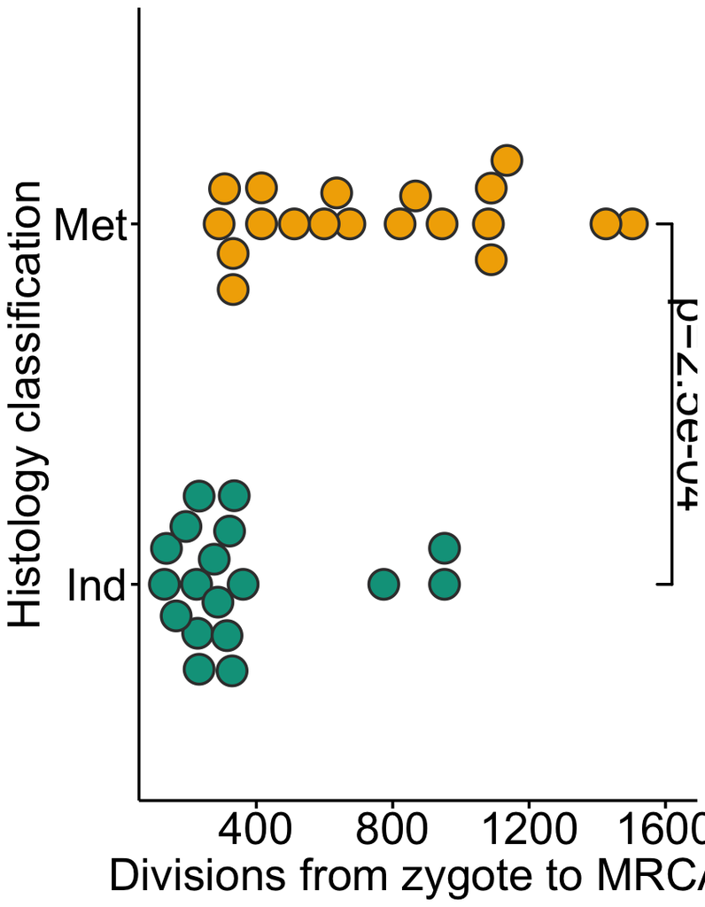

```r
clinical_divs %>%
      filter(Histology %in% c("Ind", "Met")) %>%
      ggplot(aes(Histology, divs)) +
      geom_beeswarm(aes(fill = Histology),
        cex = 5, size = 9, color = "grey23",
        pch = 21, stroke = 1.5, show.legend = FALSE
      ) +
      stat_pvalue_manual(p_hist, label = "p", tip.length = 0.03, bracket.nudge.y = 50,
      step.increase = 0.01, size = 12, bracket.size = 1, coord.flip = TRUE) +
      scale_fill_manual(values = c(
        "Ind" = wes_palette("Darjeeling1")[2], "Met" = wes_palette("Darjeeling1")[3]
      )) +
       scale_y_continuous(breaks=c( 400,800,1200, 1600)) +
      coord_flip() +
      labs(x = "Histology classification", y = "Divisions from zygote to MRCA") +
        theme_martin() +
        theme(legend.title = element_blank(), legend.position = c(0.2, 0.5), legend.text = element_text(size=18))
ggsave("../plots/Figure4/Fig4G.pdf", height=10, width=11)
```

```r
p_ngs <- clinical_divs %>%
    filter(NGS %in% c("Ind", "Met")) %>%
    wilcox_test(divs ~ NGS) %>%
    add_xy_position() %>%
    mutate(p = paste0("p=", format(p, scientific = T)))
p_ngs
```

A rstatix_test: 1 x 11

| .y. <chr> | group1 <chr> | group2 <chr> | n1 <int> | n2 <int> | statistic <dbl> | p <chr> | y.position <dbl> | groups <named list> | xmin <dbl> | xmax <dbl> |
| --- | --- | --- | --- | --- | --- | --- | --- | --- | --- | --- |
| divs | Ind | Met | 15 | 21 | 11 | p=2.78e-06 | 1639.806 | Ind, Met | 1 | 2 |

```r
clinical_divs %>%
      filter(NGS %in% c("Ind", "Met")) %>%
      count(NGS)
```

A tibble: 2 x 2

| NGS <chr> | n <int> |
| --- | --- |
| Ind | 15 |
| Met | 21 |

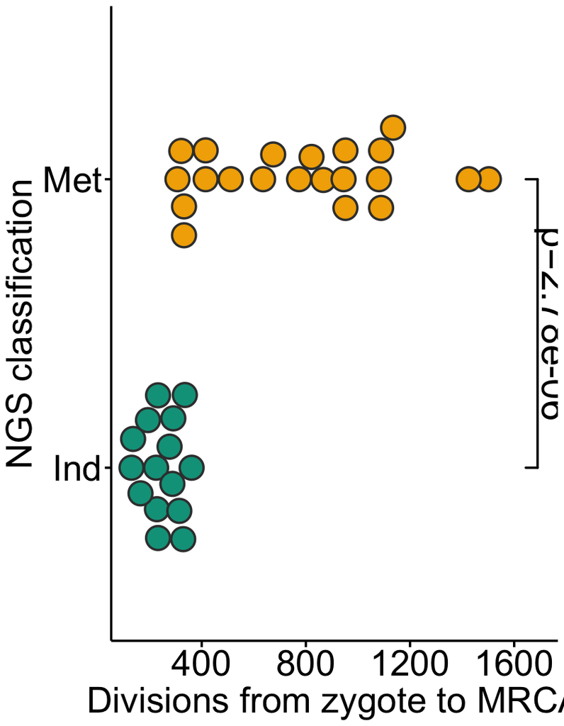

```r
clinical_divs %>%
      filter(NGS %in% c("Ind", "Met")) %>%
      ggplot(aes(NGS, divs)) +
      geom_beeswarm(aes(fill = NGS),
        cex = 5, size = 9, color = "grey23",
        pch = 21, stroke = 1.5, show.legend = FALSE
      ) +
      stat_pvalue_manual(p_ngs, label = "p", tip.length = 0.03, bracket.nudge.y = 50,
      step.increase = 0.01, size = 12, bracket.size = 1, coord.flip = TRUE) +
      scale_fill_manual(values = c(
        "Ind" = wes_palette("Darjeeling1")[2], "Met" = wes_palette("Darjeeling1")[3]
      )) +
       scale_y_continuous(breaks=c(400,800,1200, 1600)) +
      coord_flip() +
      labs(x = "NGS classification", y = "Divisions from zygote to MRCA") +
        theme_martin() +
        theme(legend.title = element_blank(), legend.position = c(0.2, 0.5), legend.text = element_text(size=18))
ggsave("../plots/Figure4/Fig4H.pdf", height=10, width=11)
```

## Figure 4I

```r
# setting up table
ln_tbl <- lung_mrca_tbl %>%
      pivot_longer(2:5, names_to = "mrca", values_to = "divs") %>%
      filter(mrca != "all_mrca", !is.na(divs)) %>%
      mutate(
            tumor_a = str_split(mrca, "_") %>% purrr::map(1) %>% toupper(),
            tumor_b = str_split(mrca, "_") %>% purrr::map(2) %>% toupper()
      ) %>%
      select(-mrca) %>%
          left_join(clinical_info_pairwise) %>%
          filter(!is.na(lobe)) %>%
          mutate(
              location = case_when(
                  lobe == lobe_2 ~ "Same lobe",
                  str_sub(lobe, start = 1, end = 1) == str_sub(lobe_2, start = 1, end = 1) ~ "Same lung",
                  TRUE ~ "Other lung"
              ), location = fct_relevel(location, "Same lobe", "Same lung", "Other lung")
          ) %>%
    group_by(subject) %>%
    slice_max(divs) %>%
    mutate(
        status = ifelse(divs > 520, "met", "ind"), n_stage = as.integer(str_sub(n_stage, 1, 1)),
        n_yes = ifelse(n_stage == 0, "Absent", "Present")
    )

ln_divs_p <- ln_tbl %>%
    ungroup() %>%
    wilcox_test(divs ~ n_yes) %>%
    add_xy_position(x = "n_yes") %>%
    mutate(y.position = 1600)  %>%
    p_format(trailing.zero = TRUE,  accuracy = 1e-03, add.p = TRUE) %>%
    mutate(p=str_pad(p, 7, "0", side="right"))
```

```r
ln_tbl %>%
    ungroup() %>%
    count(n_yes)
```

A tibble: 2 x 2

| n_yes <chr> | n <int> |
| --- | --- |
| Absent | 22 |
| Present | 12 |

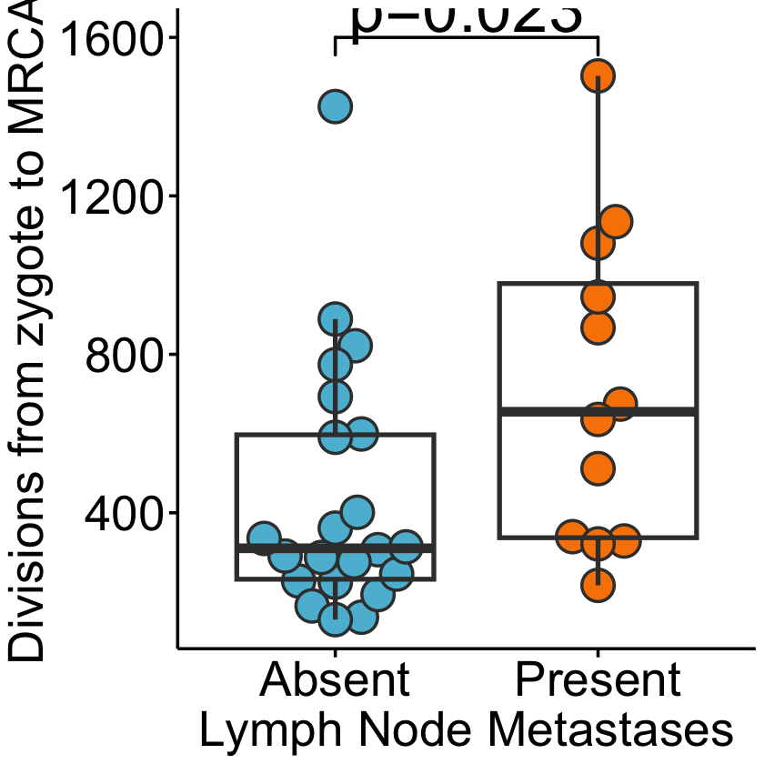

```r
ln_tbl %>%
    ggplot(aes(n_yes, divs)) +
    geom_beeswarm(aes(fill = n_yes), cex = 5, size = 9, color = "grey23",
      pch = 21, stroke = 1.5, show.legend = FALSE
    ) +
    geom_boxplot(outlier.alpha = 0, alpha = 0, linewidth = 1.5, color = "grey23") +
    stat_pvalue_manual(ln_divs_p, label = "p", tip.length = 0.03, step.increase = 0.01, size = 15, bracket.size = 1) +
    scale_fill_manual(values = c("Absent" = wes_palette("Darjeeling1")[5], "Present" = wes_palette("Darjeeling1")[4]),
      name="Lymphatic \nmetastases") +
    labs(y = "Divisions from zygote to MRCA", x = "Lymph Node Metastases") +
      theme_martin()

ggsave("../plots/Figure4/Fig4I.pdf", height=10, width=11)
```

## Fig4J

```r
status_l1 <- lung_mrca_tbl %>%
      pivot_longer(2:5, names_to = "mrca", values_to = "divs") %>%
      filter(mrca != "all_mrca", !is.na(divs)) %>%
      mutate(
            tumor_a = str_split(mrca, "_") %>% purrr::map(1) %>% toupper(),
            tumor_b = str_split(mrca, "_") %>% purrr::map(2) %>% toupper()
      ) %>%
      select(-mrca) %>%
          left_join(clinical_info_pairwise) %>%
          mutate(
              location = case_when(
                  lobe == lobe_2 ~ "Same lobe",
                  str_sub(lobe, start = 1, end = 1) == str_sub(lobe_2, start = 1, end = 1) ~ "Same lung",
                  TRUE ~ "Other lung"
              ), location = fct_relevel(location, "Same lobe", "Same lung", "Other lung")
          ) %>%
    group_by(subject) %>%
    slice_max(divs) %>%
    mutate(
        status = ifelse(divs > 520, "met", "ind"), n_stage = as.integer(str_sub(n_stage, 1, 1)),
        n_yes = ifelse(n_stage == 0, "Absent", "Present")
    )

# creating overall survival km
osurv_l1 <- status_l1 %>%
  surv_fit(Surv(os, survival) ~ status, data=.)

# creating progression free survival km
pfsurv_l1 <- status_l1 %>%
  surv_fit(Surv(pfs, pf_survival) ~ status, data=.)
```

```r
# need to setup a zero point for the km models
zero_point <- fortify(osurv_l1) %>%
    group_by(strata) %>%
    mutate(across(c(time:n.censor, std.err), ~0),
           across(c(surv, upper, lower), ~1)
    ) %>%
    distinct()
```

PFS

```r
# converting the km model into a table for plotting
plot_pfs_data <-  fortify(pfsurv_l1) %>%
   group_by(strata) %>%
   bind_rows(zero_point) %>%
   mutate(n.risk=ifelse(n.event == 0 & n.censor == 0, max(n.risk), n.risk))

# calculating a log rank p-value from the model
pval <- surv_pvalue(pfsurv_l1)$pval

# creating the KM curve
pfs_km <- ggplot(plot_pfs_data, aes(time, surv)) +
   geom_step(aes(color = strata), size = 4) +
   geom_point(
      data = subset(plot_pfs_data, n.censor > 0), aes(color = strata),
      shape = 3, stroke = 4, size=2.5
   ) +
   annotate("text", 15,0.05,label=ifelse(pval<0.001, "p < 0.001", paste0("p = ", round(pval, 3))), size=10) +
    coord_cartesian(ylim = c(0, 1)) +
       scale_x_continuous(breaks = seq(0, 100, 25)) +
       scale_color_manual(values = c(met = wes_palette("Darjeeling1")[3], ind = wes_palette("Darjeeling1")[2]), guide = "none") +
       labs(y = "Progression free\nsurvival") +
       theme_martin() +
       theme(
          axis.line.x = element_line(size = 2),
          axis.ticks.x = element_blank(),
          axis.title.x = element_blank(),
          axis.title.y = element_text(vjust = 0)
       )
```

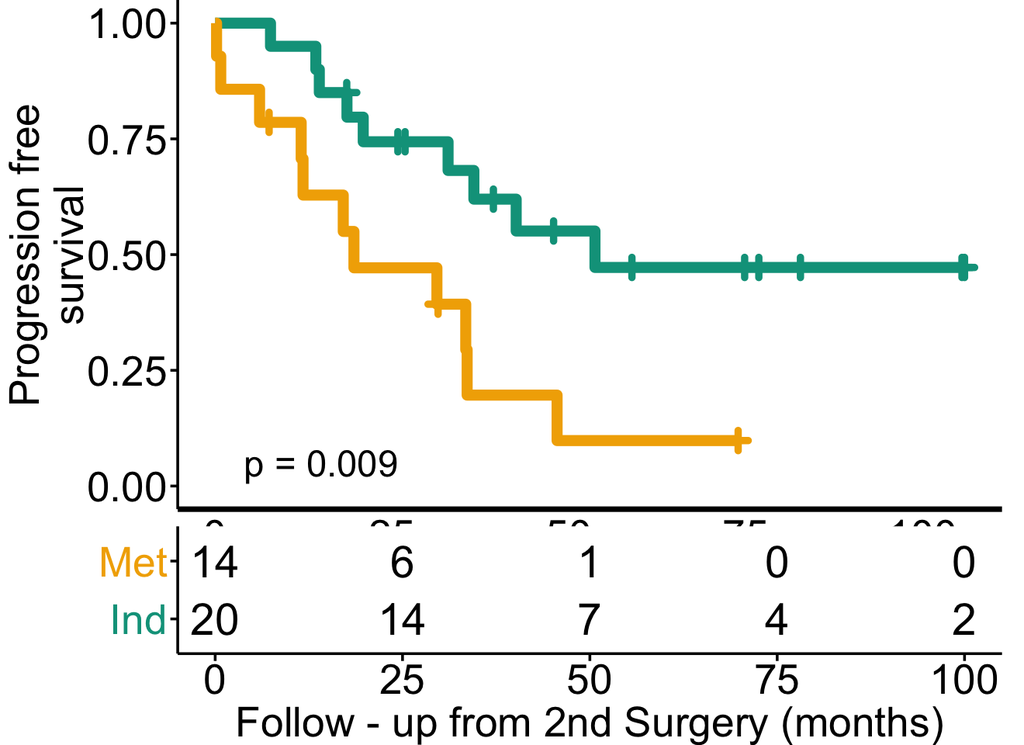

```r
options(repr.plot.width = 11, repr.plot.height = 8)

# adding risk table
pfs_risk_table <- plot_pfs_data %>%
   mutate(time = cut(time, seq(0, 125, 25), include.lowest = TRUE, labels = seq(0, 100, 25))) %>%
   group_by(strata, time) %>%
   slice_max(n.risk, with_ties = FALSE) %>%
   select(n.risk, time, strata) %>%
   pivot_wider(values_from = n.risk, names_from = time) %>%
   replace(is.na(.), 0) %>%
   pivot_longer(-strata, names_to = "time", values_to = "n") %>%
   mutate(time = as.integer(time), strata = fct_relevel(strata, "ind", "met")) %>%
   ggplot(aes(time, strata)) +
   geom_text(aes(label = n), size = 12) +
   scale_y_discrete(labels = c(ind = "Ind", met = "Met")) +
   labs(x = "Follow - up from 2nd Surgery (months)") +
   theme_martin() +
   theme(axis.title.y = element_blank(), axis.text.y = element_text(color = c(
      wes_palette("Darjeeling1")[2],
      wes_palette("Darjeeling1")[3]
   )))

# combining risk table and km curves directly onto each other
(pfs_km / plot_spacer() / pfs_risk_table) +
   patchwork::plot_layout(
      ncol = 1, nrow = 3,
      heights = c(4, -0.25, 1)
   ) &
   theme(plot.margin = unit(c(0, 0.3, 0, 0), "cm"))

ggsave("../plots/Figure4/Fig4J.pdf", height=10, width=12)
```

OS:

```r
# converting the km model into a table for plotting
plot_os_data <- fortify(osurv_l1) %>%
   group_by(strata) %>%
   bind_rows(zero_point) %>%
   mutate(n.risk=ifelse(n.event == 0 & n.censor == 0, max(n.risk), n.risk))

# calculating a log rank p-value from the model
pval <- surv_pvalue(osurv_l1)$pval

# creating the KM curve
os_km <- ggplot(plot_os_data, aes(time, surv)) +
     geom_step(aes(color = strata), size = 4) +
   geom_point(
      data = subset(plot_os_data, n.censor > 0), aes(color = strata),
      shape = 3, stroke = 4, size=2.5
   ) +
   annotate("text" ,x=15,y=0.05,label=ifelse(pval<0.001, "p < 0.001", paste0("p = ", round(pval, 3))), size=10) +
    coord_cartesian(ylim = c(0, 1)) +
       scale_x_continuous(breaks = seq(0, 100, 25)) +
       scale_color_manual(values = c(met = wes_palette("Darjeeling1")[3], ind = wes_palette("Darjeeling1")[2]), guide = "none") +
       labs(y = "Overall survival", x = "Follow - up from 2nd Surgery (months)") +
       theme_martin() +
       theme(
          axis.line.x = element_line(size = 2),
          axis.ticks.x = element_blank(),
          axis.title.x = element_blank()
       )
```

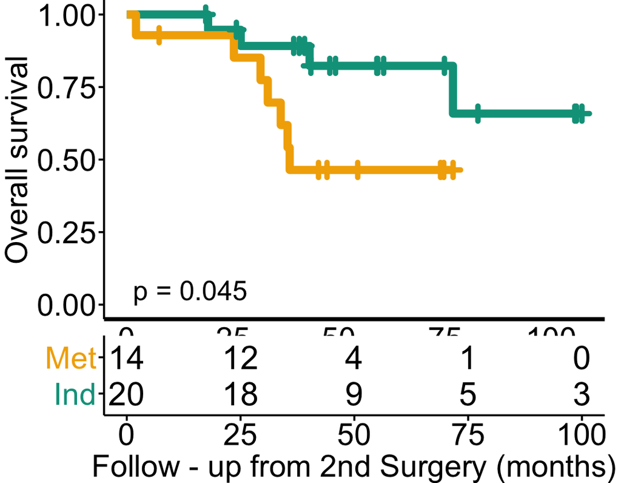

```r
options(repr.plot.width = 9, repr.plot.height = 7)

# adding risk table
os_risk_table <- plot_os_data %>%
   mutate(time = cut(time, seq(0, 125, 25), include.lowest = TRUE, labels = seq(0, 100, 25))) %>%
   group_by(strata, time) %>%
   slice_max(n.risk, with_ties = FALSE) %>%
   select(n.risk, time, strata) %>%
   pivot_wider(values_from = n.risk, names_from = time) %>%
   replace(is.na(.), 0) %>%
   pivot_longer(-strata, names_to = "time", values_to = "n") %>%
   mutate(time = as.integer(time), strata = fct_relevel(strata, "ind", "met")) %>%
   ggplot(aes(time, strata)) +
   geom_text(aes(label = n), size = 12) +
   scale_y_discrete(labels = c(ind = "Ind", met = "Met")) +
   labs(x = "Follow - up from 2nd Surgery (months)") +
   theme_martin() +
   theme(axis.title.y = element_blank(), axis.text.y = element_text(color = c(
      wes_palette("Darjeeling1")[2],
      wes_palette("Darjeeling1")[3]
   )))

# combining risk table and km curves directly onto each other
(os_km / plot_spacer() / os_risk_table) +
   patchwork::plot_layout(
      ncol = 1, nrow = 3,
      heights = c(4, -0.25, 1)
   ) &
   theme(plot.margin = unit(c(0,0.3,0,0.1), "cm"))

ggsave("../plots/Figure4/Extended_Data_Fig7d.pdf", height=10, width=12)
```

Cox model

```r
cox_multi_pfs <- coxph(Surv(pfs, pf_survival)  ~  divs, data = status_l1, x = TRUE)
summary(cox_multi_pfs)
```

```
Call:
coxph(formula = Surv(pfs, pf_survival) ~ divs, data = status_l1,
    x = TRUE)

  n= 34, number of events= 20

          coef exp(coef)  se(coef)     z Pr(>|z|)
divs 0.0019389 1.0019408 0.0006148 3.154  0.00161 **
---
Signif. codes:  0 '***' 0.001 '**' 0.01 '*' 0.05 '.' 0.1 ' ' 1

     exp(coef) exp(-coef) lower .95 upper .95
divs     1.002     0.9981     1.001     1.003

Concordance= 0.703  (se = 0.056 )
Likelihood ratio test= 9.22  on 1 df,   p=0.002
Wald test            = 9.95  on 1 df,   p=0.002
Score (logrank) test = 11.14  on 1 df,   p=8e-04
```

```r
cox_multi_os <- coxph(Surv(os, survival)  ~  divs, data = status_l1, x = TRUE)
summary(cox_multi_os)
```

```
Call:
coxph(formula = Surv(os, survival) ~ divs, data = status_l1,
    x = TRUE)

  n= 34, number of events= 11

          coef exp(coef)  se(coef)     z Pr(>|z|)
divs 0.0013831 1.0013840 0.0007116 1.944   0.0519 .
---
Signif. codes:  0 '***' 0.001 '**' 0.01 '*' 0.05 '.' 0.1 ' ' 1

     exp(coef) exp(-coef) lower .95 upper .95
divs     1.001     0.9986         1     1.003

Concordance= 0.687  (se = 0.084 )
Likelihood ratio test= 3.41  on 1 df,   p=0.06
Wald test            = 3.78  on 1 df,   p=0.05
Score (logrank) test = 4.05  on 1 df,   p=0.04
```

## Fig 4K

```r
ind_subjects <- lung_mrca_tbl  %>%
    pivot_longer(2:5, names_to="mrca", values_to="divs") %>%
    filter(mrca!="all_mrca", !is.na(divs))  %>%
    mutate(row_id=as.factor(row_number()),
          tumor_a=str_split(mrca, "_")  %>% purrr::map(1)  %>% toupper(),
          tumor_b=str_split(mrca, "_")  %>% purrr::map(2)  %>% toupper())  %>%
    pivot_longer(tumor_a:tumor_b, values_to="tumor_b", names_to="x")   %>%
    left_join(lung_normal  %>%
                rename(divs_n=divs))  %>%
    group_by(subject, mrca) %>%
    filter(divs < 520) %>%
    pull(subject) %>%
    unique()
```

```r
divs_by_timing <-  lung_mrca_tbl  %>%
    pivot_longer(2:5, names_to="mrca", values_to="divs") %>%
    filter(mrca!="all_mrca", !is.na(divs))  %>%
    mutate(row_id=as.factor(row_number()),
          tumor_a=str_split(mrca, "_")  %>% purrr::map(1)  %>% toupper(),
          tumor_b=str_split(mrca, "_")  %>% purrr::map(2)  %>% toupper())  %>%
    pivot_longer(tumor_a:tumor_b, values_to="tumor_b", names_to="x")   %>%
    left_join(lung_normal  %>%
                rename(divs_n=divs))  %>%
    group_by(subject, mrca)  %>%
    unite(subject, mrca, col = "id", remove=F) %>%
    mutate(id=str_remove(id, "_mrca")  %>%
                      toupper()  %>%
                      str_replace_all("_", " "))  %>%
    mutate(
        id = fct_reorder(id, divs, max),
        status = ifelse(divs < 520, "ind", "met")
    ) %>%
    left_join(join_ngs_names) %>%
        filter(NGS == "IPM") %>%
        left_join(select(clinical_info_pairwise, -tumor_a, -tumor_b), join_by(id, subject)) %>%
        select(subject, id, divs, divs_n, NGS, interval, tumor_b) %>%
        mutate(Resection = ifelse(tumor_b == "P1", "First", "Second")) %>%
        filter(interval != 0)
```

```r
res_timining_p <- divs_by_timing %>%
    group_by(subject, Resection) %>%
    summarize(divs_n = mean(divs_n)) %>%
    ungroup() %>%
    wilcox_test(divs_n ~ Resection, paired = TRUE) %>%
    add_xy_position() %>%
    p_format(trailing.zero = TRUE,  accuracy = 1e-03, add.p = TRUE) %>%
    mutate(p=str_pad(p, 7, "0", side="right"))
```

```r
divs_by_timing %>%
    ungroup() %>%
    select(subject, divs_n, Resection) %>%
    distinct() %>%
    group_by(subject, Resection) %>%
    summarize(divs_n = mean(divs_n)) %>%
    ungroup() %>%
    count(Resection)
```

A tibble: 2 x 2

| Resection <chr> | n <int> |
| --- | --- |
| First | 7 |
| Second | 7 |

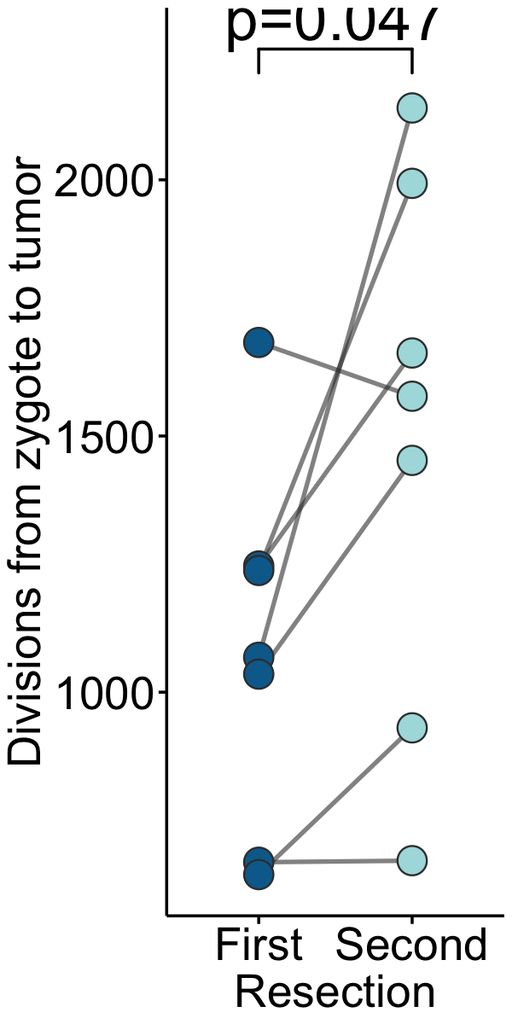

```r
divs_by_timing %>%
    ungroup() %>%
    select(subject, divs_n, Resection)  %>%
    distinct() %>%
    group_by(subject, Resection) %>%
    summarize(divs_n=mean(divs_n)) %>%
    ggplot(aes(Resection, divs_n)) +
    geom_line(aes(group = subject), color = "grey23", size = 1.5, alpha = 0.6) +
    geom_point(aes(fill=Resection), color = "grey23",  size = 9, pch=21, stroke=1, show.legend = FALSE ) +
    scale_fill_manual(values = c("First" = wes_palette("Darjeeling2")[2], "Second" = wes_palette("Darjeeling2")[4])) +
    stat_pvalue_manual(res_timining_p, label = "p", tip.length = 0.03, step.increase = 0.01, size = 15, bracket.size = 1, bracket.nudge.y=60) +
    labs(y="Divisions from zygote to tumor") +
    theme_martin() +
    theme(text = element_text(size = 20, color="black"),
         axis.text = element_text(color="black"),
         axis.ticks = element_line(color="black"))
ggsave("../plots/Figure4/Fig4K.pdf", height=10, width=10)
```

```r
ind_resection <- lung_mrca_tbl  %>%
    pivot_longer(2:5, names_to="mrca", values_to="divs") %>%
    filter(mrca!="all_mrca", !is.na(divs))  %>%
    mutate(row_id=as.factor(row_number()),
          tumor_a=str_split(mrca, "_")  %>% purrr::map(1)  %>% toupper(),
          tumor_b=str_split(mrca, "_")  %>% purrr::map(2)  %>% toupper())  %>%
    pivot_longer(tumor_a:tumor_b, values_to="tumor_b", names_to="x")   %>%
    left_join(lung_normal  %>%
                rename(divs_n=divs))  %>%
    group_by(subject, mrca)  %>%
    unite(subject, mrca, col = "id", remove=F) %>%
    mutate(id=str_remove(id, "_mrca")  %>%
                      toupper()  %>%
                      str_replace_all("_", " "))  %>%
    mutate(id = fct_reorder(id, divs, max)) %>%
    left_join(join_ngs_names) %>%
    filter(NGS == "SPLC") %>%
    left_join(select(clinical_info_pairwise, -tumor_a, -tumor_b), join_by(id, subject)) %>%
    select(subject, id, divs, divs_n, NGS, interval, tumor_b) %>%
    mutate(Resection = ifelse(tumor_b == "P1", "First", "Second")) %>%
    filter(interval != 0) %>%
    ungroup() %>%
    select(subject, divs_n, Resection)  %>%
    distinct() %>%
    group_by(subject, Resection) %>%
    summarize( divs_n=mean(divs_n))
```

```r
ind_res_timining_p <- ind_resection %>%
    ungroup() %>%
    wilcox_test(divs_n ~ Resection, paired = TRUE) %>%
    add_xy_position() %>%
    p_format(trailing.zero = TRUE, accuracy = 1e-03, add.p = TRUE) %>%
    mutate(p = str_pad(p, 7, "0", side = "right"))
ind_res_timining_p
```

A rstatix_test: 1 x 11

| .y. <chr> | group1 <chr> | group2 <chr> | n1 <int> | n2 <int> | statistic <dbl> | p <chr> | y.position <dbl> | groups <named list> | xmin <dbl> | xmax <dbl> |
| --- | --- | --- | --- | --- | --- | --- | --- | --- | --- | --- |
| divs_n | First | Second | 7 | 7 | 24 | p=0.110 | 1384.54 | First , Second | 1 | 2 |

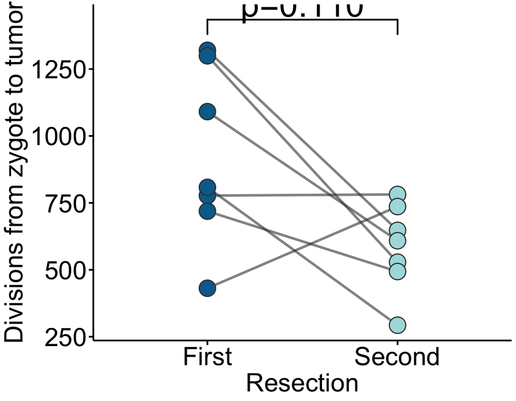

```r
ind_resection %>%
    ggplot(aes(Resection, divs_n)) +
    geom_line(aes(group = subject), color = "grey23", size = 1.5, alpha = 0.6) +
    geom_point(aes(fill=Resection), color = "grey23",  size = 9, pch=21, stroke=1, show.legend = FALSE ) +
    scale_fill_manual(values = c("First" = wes_palette("Darjeeling2")[2], "Second" = wes_palette("Darjeeling2")[4])) +
    stat_pvalue_manual(ind_res_timining_p, label = "p", tip.length = 0.05, step.increase = 0.01, size = 15, bracket.size = 1, bracket.nudge.y=50) +
    labs(y="Divisions from zygote to tumor") +
    theme_martin() +
    theme(text = element_text(size = 20, color="black"),
         axis.text = element_text(color="black"),
         axis.ticks = element_line(color="black"))
ggsave("../plots/Figure4/Extended_Data_Fig7e.pdf", height = 11, width = 10)
```

### Death birth ratios

```r
crc_birth_death <- read_tsv("../results/crc_death_birth_rates.tsv")
```

```r
death_birth_tbl <-  lung_mrca_tbl  %>%
    pivot_longer(2:5, names_to="mrca", values_to="divs") %>%
    filter(mrca!="all_mrca", !is.na(divs))  %>%
    mutate(row_id=as.factor(row_number()),
          tumor_a=str_split(mrca, "_")  %>% purrr::map(1)  %>% toupper(),
          tumor_b=str_split(mrca, "_")  %>% purrr::map(2)  %>% toupper())  %>%
    pivot_longer(tumor_a:tumor_b, values_to="tumor_b", names_to="x")   %>%
    left_join(lung_normal  %>%
                rename(divs_n=divs))  %>%
    group_by(subject, mrca)  %>%
    unite(subject, mrca, col = "id", remove=F) %>%
    mutate(id=str_remove(id, "_mrca")  %>%
                      toupper()  %>%
                      str_replace_all("_", " "))  %>%
    mutate(
        id = fct_reorder(id, divs, max),
        status = ifelse(divs < 520, "ind", "met")
    ) %>%
    left_join(join_ngs_names) %>%
        filter(NGS == "IPM") %>%
        left_join(select(clinical_info_pairwise, -tumor_a, -tumor_b), join_by(id, subject)) %>%
        mutate(divs_n = divs_n - divs) %>%
        select(subject, id, divs, divs_n, NGS, interval, tumor_b, size_a, size_b) %>%
        mutate(Resection = ifelse(tumor_b == "P1", "First", "Second"), size = ifelse(tumor_b == "P1", size_a, size_b)) %>%
        filter(interval != 0, Resection == "First") %>%
        group_by(subject, tumor_b) %>%
        slice_min(divs_n, with_ties = F) %>%
        mutate(
            volume = pi / 6 * size * (size / 2)^2, cell_count = volume * 10e8, death_birth_ratio = ((divs_n / 2) - log(cell_count)) / (divs_n / 2)
        ) %>%
        ungroup() %>%
        mutate(MSS_status="lung")%>%
        bind_rows(crc_birth_death)
```

```r
death_birth_tbl %>%
    group_by(MSS_status) %>%
    summarize(median(death_birth_ratio), format(median(cell_count), scientific=T), median(divs_n), n = n())
```

A tibble: 3 x 5

| MSS_status <chr> | median(death_birth_ratio) <dbl> | format(median(cell_count), scientific = T) <chr> | median(divs_n) <dbl> | n <int> |
| --- | --- | --- | --- | --- |
| MSI | 0.9442639 | 7.125374e+10 | NA | 6 |
| MSS | 0.9433236 | 1.192823e+10 | NA | 31 |
| lung | 0.8535586 | 2.300693e+09 | 292.8255 | 7 |

```r
lung_mrca_tbl  %>%
    pivot_longer(2:5, names_to="mrca", values_to="divs") %>%
    filter(mrca!="all_mrca", !is.na(divs))  %>%
    mutate(row_id=as.factor(row_number()),
          tumor_a=str_split(mrca, "_")  %>% purrr::map(1)  %>% toupper(),
          tumor_b=str_split(mrca, "_")  %>% purrr::map(2)  %>% toupper())  %>%
    pivot_longer(tumor_a:tumor_b, values_to="tumor_b", names_to="x")   %>%
    left_join(lung_normal  %>%
                rename(divs_n=divs))  %>%
    group_by(subject, mrca)  %>%
    unite(subject, mrca, col = "id", remove=F) %>%
    mutate(id=str_remove(id, "_mrca")  %>%
                      toupper()  %>%
                      str_replace_all("_", " "))  %>%
    mutate(
        id = fct_reorder(id, divs, max),
        status = ifelse(divs < 520, "ind", "met")
    ) %>%
    left_join(join_ngs_names) %>%
        filter(NGS == "IPM") %>%
        left_join(select(clinical_info_pairwise, -tumor_a, -tumor_b), join_by(id, subject)) %>%
        mutate(divs_n = divs_n - divs) %>%
        select(subject, id, divs, divs_n, NGS, interval, tumor_b, size_a, size_b) %>%
        mutate(Resection = ifelse(tumor_b == "P1", "First", "Second"), size = ifelse(tumor_b == "P1", size_a, size_b)) %>%
        filter(interval != 0, Resection == "First") %>%
        group_by(subject, tumor_b) %>%
        slice_min(divs_n, with_ties = F) %>%
        mutate(
        volume = (pi*size^3)/6, cell_count = volume * 10e8, death_birth_ratio = ((divs_n / 2) - log(cell_count)) / (divs_n / 2)
        ) %>%
        ungroup() %>%
        mutate(MSS_status="lung")%>%
        bind_rows(crc_birth_death) %>%
group_by(MSS_status) %>%
    summarize(median(death_birth_ratio), format(median(cell_count), scientific=T), median(pt_divs), n = n())
```

A tibble: 3 x 5

| MSS_status <chr> | median(death_birth_ratio) <dbl> | format(median(cell_count), scientific = T) <chr> | median(pt_divs) <dbl> | n <int> |
| --- | --- | --- | --- | --- |
| MSI | 0.9442639 | 7.125374e+10 | 910.7904 | 6 |
| MSS | 0.9433236 | 1.192823e+10 | 799.7295 | 31 |
| lung | 0.8441410 | 9.202772e+09 | NA | 7 |

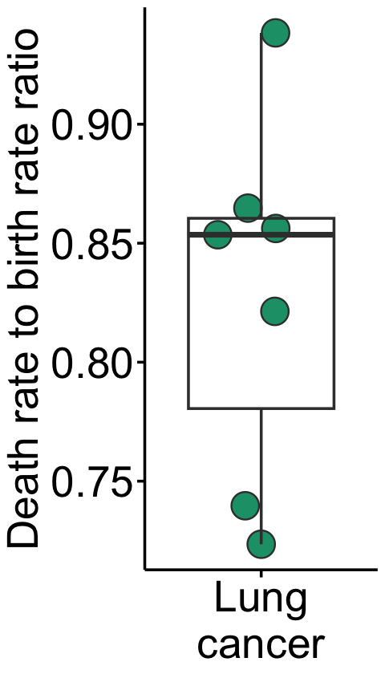

```r
options(repr.plot.width=4, repr.plot.height=7)
lung_mrca_tbl  %>%
    pivot_longer(2:5, names_to="mrca", values_to="divs") %>%
    filter(mrca!="all_mrca", !is.na(divs))  %>%
    mutate(row_id=as.factor(row_number()),
          tumor_a=str_split(mrca, "_")  %>% purrr::map(1)  %>% toupper(),
          tumor_b=str_split(mrca, "_")  %>% purrr::map(2)  %>% toupper())  %>%
    pivot_longer(tumor_a:tumor_b, values_to="tumor_b", names_to="x")   %>%
    left_join(lung_normal  %>%
                rename(divs_n=divs))  %>%
    group_by(subject, mrca)  %>%
    unite(subject, mrca, col = "id", remove=F) %>%
    mutate(id=str_remove(id, "_mrca")  %>%
                      toupper()  %>%
                      str_replace_all("_", " "))  %>%
    mutate(
        id = fct_reorder(id, divs, max),
        status = ifelse(divs < 520, "ind", "met")
    ) %>%
    left_join(join_ngs_names) %>%
        filter(NGS == "IPM") %>%
        left_join(select(clinical_info_pairwise, -tumor_a, -tumor_b), join_by(id, subject)) %>%
        mutate(divs_n = divs_n - divs) %>%
        select(subject, id, divs, divs_n, NGS, interval, tumor_b, size_a, size_b) %>%
        mutate(Resection = ifelse(tumor_b == "P1", "First", "Second"), size = ifelse(tumor_b == "P1", size_a, size_b)) %>%
        filter(interval != 0, Resection == "First") %>%
        group_by(subject, tumor_b) %>%
        slice_min(divs_n, with_ties = F) %>%
        mutate(
            volume = pi / 6 * size * (size / 2)^2, cell_count = volume * 10e8, death_birth_ratio = ((divs_n / 2) - log(cell_count)) / (divs_n / 2)
        ) %>%
        ungroup() %>%
            mutate(MSS_status = "lung") %>%
            ggplot(aes(MSS_status, death_birth_ratio)) +
            geom_quasirandom(aes(fill = MSS_status), fill = "#1B9E77", width = 0.3, size = 9, pch = 21, color = "grey23", stroke = 1) +
            geom_boxplot(alpha = 0, size = 1, color = "grey23") +
            # stat_pvalue_manual(msi_mss_p, tip.length = 0.03, step.increase = 0.01, size = 10, bracket.size = 1, bracket.nudge.y = 100) +
            scale_x_discrete(labels = c("Lung\ncancer")) +
            # coord_cartesian(ylim=c(0,6000)) +
            labs(y = "Death rate to birth rate ratio") +
            theme_martin() +
            theme(axis.title.x = element_blank())
    ggsave("../plots/Supplementary_figures/SupNote5Fig2.pdf", height=7, width=4)
```

## Fig 4L

```r
pairwise_tumors <- lung_mrca_tbl  %>%
    pivot_longer(2:5, names_to="mrca", values_to="divs") %>%
    filter(mrca!="all_mrca", !is.na(divs))  %>%
    mutate(row_id=as.factor(row_number()),
          tumor_a=str_split(mrca, "_")  %>% purrr::map(1)  %>% toupper(),
          tumor_b=str_split(mrca, "_")  %>% purrr::map(2)  %>% toupper())  %>%
    pivot_longer(tumor_a:tumor_b, values_to="tumor_b", names_to="x")   %>%
    left_join(lung_normal  %>%
                rename(divs_n=divs))  %>%
    group_by(subject, mrca)  %>%
    unite(subject, mrca, col = "id", remove=F) %>%
    mutate(id=str_remove(id, "_mrca")  %>%
                      toupper()  %>%
                      str_replace_all("_", " "))  %>%
    mutate(
        id = fct_reorder(id, divs, max),
        status = ifelse(divs < 520, "ind", "met")
    ) %>%
    select(subject, id, x, divs_n, status) %>%
    pivot_wider(names_from = x, values_from = divs_n) %>%
    left_join(join_ngs_names, by = c("id", "subject"))  %>%
    filter(NGS %in% c("SPLC", "IPM")) %>%
    mutate(across(c(NGS, Histology), ~ case_match(.x, "IPM" ~ "Met", "SPLC" ~ "Ind")))
```

```r
p_values <- pairwise_tumors %>%
    group_by(NGS) %>%
    cor_test(tumor_a, tumor_b) %>%
    p_format(accuracy = 0.001, digits = 1, add.p = TRUE)
p_ipm <- paste0("Met\n", p_values[p_values$NGS=="Met",]$p)
p_SPLC <- paste0("Ind\n", p_values[p_values$NGS=="Ind",]$p)
```

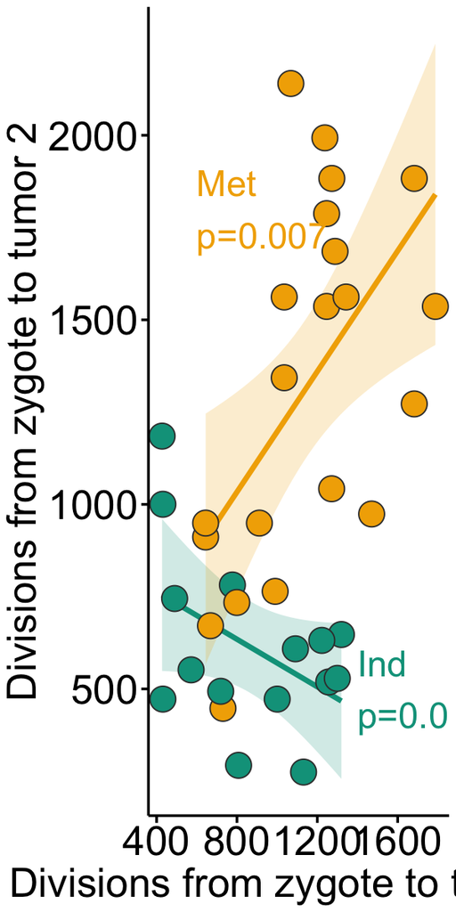

```r
pairwise_tumors %>%
  ggplot(aes(tumor_a, tumor_b, color = NGS, fill = NGS)) +
    geom_smooth(method = "lm", size = 2, alpha = 0.2, show.legend = F) +
    geom_point(aes(), size = 9, color = "grey23",
      pch = 21, stroke = 0.8, show.legend = F
    ) +
    annotate("text", 600, 1800, label =p_ipm, hjust = 0, size = 10, color = wes_palette("Darjeeling1")[3]) +
      annotate("text",1400,500,label=p_SPLC, hjust=0, size=10, color=wes_palette("Darjeeling1")[2]) +
    scale_color_manual(values = c("Ind" = wes_palette("Darjeeling1")[2], "Met" = wes_palette("Darjeeling1")[3])) +
    scale_fill_manual(values = c("Ind" = wes_palette("Darjeeling1")[2], "Met" = wes_palette("Darjeeling1")[3])) +
    labs(x = "Divisions from zygote to tumor 1", y = "Divisions from zygote to tumor 2") +
    theme_martin()
ggsave("../plots/Figure4/Fig4L.pdf", height = 11, width = 14)
```

# Fig 4M

```r
# setting up the data
divs_per_pair <- lung_mrca_tbl  %>%
    pivot_longer(2:5, names_to="mrca", values_to="divs") %>%
    filter(mrca!="all_mrca", !is.na(divs))  %>%
    mutate(row_id=as.factor(row_number()),
          tumor_a=str_split(mrca, "_")  %>% purrr::map(1)  %>% toupper(),
          tumor_b=str_split(mrca, "_")  %>% purrr::map(2)  %>% toupper())  %>%
    pivot_longer(tumor_a:tumor_b, values_to="tumor_b", names_to="x")   %>%
    left_join(lung_normal  %>%
                rename(divs_n=divs))  %>%
    group_by(subject, mrca)  %>%
    unite(subject, mrca, col = "id", remove=F) %>%
    mutate(id=str_remove(id, "_mrca")  %>%
                      toupper()  %>%
                      str_replace_all("_", " "))  %>%
    mutate(
        id = fct_reorder(id, divs, max),
        status = ifelse(divs < 520, "ind", "met")
    ) %>%
    select(subject, id, x, divs_n, status) %>%
    left_join(join_ngs_names) %>%
    filter(NGS %in% c("SPLC", "IPM")) %>%
    group_by(id) %>%
    mutate(divs_pair = ifelse(NGS == "SPLC", mean(divs_n), min(divs_n))) %>%
    mutate(across(c(NGS, Histology), ~ case_match(.x, "IPM" ~ "Met", "SPLC" ~ "Ind"))) %>%
    select(id, divs_pair, NGS)  %>%
    distinct()
```

```r
p_divs_per_pair <- divs_per_pair %>%
    ungroup() %>%
    wilcox_test(divs_pair ~ NGS) %>%
    add_xy_position(x = "NGS") %>%
    p_format(accuracy = 0.001, digits = 1, add.p = TRUE)
```

```r
divs_per_pair %>%
    ungroup() %>%
    count(NGS)
```

A tibble: 2 x 2

| NGS <chr> | n <int> |
| --- | --- |
| Ind | 15 |
| Met | 21 |

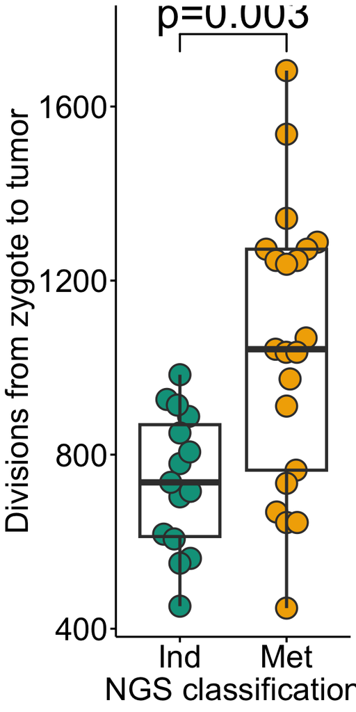

```r
divs_per_pair %>%
    ggplot(aes(NGS, divs_pair)) +
    geom_beeswarm(aes(fill = NGS), cex = 5, size = 9, color = "grey23",
      pch = 21, stroke = 1.5, show.legend = FALSE
    ) +
    geom_boxplot(outlier.alpha = 0, alpha = 0, linewidth = 1.5, color = "grey23") +
    stat_pvalue_manual(p_divs_per_pair, label = "p", tip.length = 0.03, step.increase = 0.01, size = 15, bracket.size = 1) +
    scale_fill_manual(values = c("Ind" = wes_palette("Darjeeling1")[2], "Met" = wes_palette("Darjeeling1")[3])) +
    labs(x = "NGS classification", y = "Divisions from zygote to tumor") +
    theme_martin()
ggsave("../plots/Figure4/Fig4M.pdf", height = 10, width = 12)
```

## Numbers for text

Number of patients

```r
clinical_info  %>%
    select(subject, p1_lobe, p2_lobe, p3_lobe)  %>%
    mutate(spread=case_when(p1_lobe==p2_lobe ~ "same_lobe",
                            str_sub(p1_lobe, 1,1) == str_sub(p2_lobe, 1,1) ~ "same_side",
                            TRUE ~ "other_side"))  %>%
    pivot_longer(cols = p1_lobe:p3_lobe, names_to = "tumor", values_to = "lobe") %>%
    drop_na() %>%
    pull(subject)  %>%
    n_distinct()
```

34

Number of individual tumors

```r
clinical_info  %>%
    select(subject, p1_lobe, p2_lobe, p3_lobe)  %>%
    mutate(spread=case_when(p1_lobe==p2_lobe ~ "same_lobe",
                            str_sub(p1_lobe, 1,1) == str_sub(p2_lobe, 1,1) ~ "same_side",
                            TRUE ~ "other_side"))  %>%
    pivot_longer(cols = p1_lobe:p3_lobe, names_to = "tumor", values_to = "lobe") %>%
    drop_na() %>%
    nrow()
```

73

Percentage of patients with 3 tumors

```r
clinical_info  %>%
    select(subject, p1_lobe, p2_lobe, p3_lobe)  %>%
    mutate(spread=case_when(p1_lobe==p2_lobe ~ "same_lobe",
                            str_sub(p1_lobe, 1,1) == str_sub(p2_lobe, 1,1) ~ "same_side",
                            TRUE ~ "other_side"))  %>%
    pivot_longer(cols = p1_lobe:p3_lobe, names_to = "tumor", values_to = "lobe") %>%
        drop_na() %>%
        group_by(subject) %>%
        mutate(three_p = ifelse(n() > 2, TRUE, FALSE)) %>%
        ungroup() %>%
        select(subject, three_p) %>%
        distinct() %>%
        count(three_p)
5/34*100
```

A tibble: 2 x 2

| three_p <lgl> | n <int> |
| --- | --- |
| FALSE | 29 |
| TRUE | 5 |

14.7058823529412

Number of tumor pairs

```r
lung_pairwise_l1 %>%
    drop_na() %>%
    nrow()
```

44

Cell division range from zygote to MRCA

```r
mrca_divs <- lung_mrca_tbl %>%
    pivot_longer(p1_p2_mrca:p2_p3_mrca) %>%
    drop_na() %>%
    pull(value)
```

```r
min(mrca_divs)
max(mrca_divs)
```

130.289232889772

1502.81232891676

Number of divisions from normal

```r
dist_from_normal %>%
    group_by(cohort) %>%
    summarize(median(divs), sd(divs))
```

A tibble: 2 x 3

| cohort <fct> | median(divs) <dbl> | sd(divs) <dbl> |
| --- | --- | --- |
| Lung | 911.5835 | 451.3507 |
| CRC Primary | 2431.7124 | 967.6873 |

Number of samples in TCGA

```r
tcga_norm_mut %>%
    count(TCGA)
```

A tibble: 2 x 2

| TCGA <fct> | n <int> |
| --- | --- |
| COAD | 386 |
| LUAD | 501 |

Mutation variance

```r
var(log10(tcga_norm_mut$norm_mut))
var(log10(polyg_norm_mut$norm_mut))
```

0.133064737062251

0.04113683474036

```r
max(tcga_norm_mut$norm_mut)/min(tcga_norm_mut$norm_mut)
```

791

```r
max(polyg_norm_mut$norm_mut)/min(polyg_norm_mut$norm_mut)
```

8.68193494543639

SBS1 burden variance

```r
var(log10(polyg_norm_mut$norm_mut))
var(log10(sbs1_lung$norm_mut[sbs1_lung$norm_mut>0]))
```

0.04113683474036

0.103817770766332

```r
max(sbs1_lung$norm_mut[sbs1_lung$norm_mut>0])/min(sbs1_lung$norm_mut[sbs1_lung$norm_mut>0])
```

31.3333333333333

Classification numbers

```r
lung_age %>%
    pivot_longer(p1_p2_mrca:p2_p3_mrca, names_to = "pair", values_to = "divs") %>%
    drop_na() %>%
    mutate(category = ifelse(divs > 520, "met", "ind")) %>%
    ungroup() %>%
    count(category)
26 / 44 * 100
18 / 44 * 100
```

A tibble: 2 x 2

| category <chr> | n <int> |
| --- | --- |
| ind | 26 |
| met | 18 |

59.0909090909091

40.9090909090909

Number of genotyped polyGs

```r
crc_markerlengths <- read_tsv("../results/crc_markerlengths.tsv")
```

```r
lung_markerlengths %>%
    bind_rows(crc_markerlengths) %>%
    count(subject, sample) %>%
    select(subject, n) %>%
    distinct() %>%
    summarise(mean(n))
```

A tibble: 1 x 1

| mean(n) <dbl> |
| --- |
| 24.21127 |

Data for supplementary table 2

```r
mrca_annocation <- lung_mrca_tbl  %>%
    pivot_longer(2:5, names_to="mrca", values_to="divs") %>%
    filter(mrca!="all_mrca", !is.na(divs))  %>%
    mutate(row_id=as.factor(row_number()),
          tumor_a=str_split(mrca, "_")  %>% purrr::map(1)  %>% toupper(),
          tumor_b=str_split(mrca, "_")  %>% purrr::map(2)  %>% toupper()) %>%
          select(1,3,5:6) %>%
          rename(mrca=divs)
```

```r
lung_pairwise_l1 %>%
    mutate(divs = l1 / 9.43139014888478e-05) %>%
    left_join(mrca_annocation) %>%
    select(subject:tumor_b, marker, divs, mrca, r) %>%
    mutate(subject_number = as.numeric(str_remove(subject, "TM"))) %>%
    arrange(subject_number, tumor_a, tumor_b) %>%
    select(-subject_number) %>%
    write_tsv("../results/Supplementary_table_2.tsv")
```